# Contig-Level Bacterial Diversity - Chapter 4

Contig-level composition from assembled metagenomes classified by Kraken2. Groups: ASC_CAT, EVI_CAT (BF Bolton Base + CAT); ASC_RVS, EVI_RVS (BPW + RVS enrichment).

Two normalisation strategies are shown: - **Normalised**: relative abundance (% of classified bases) and BPM - **Unnormalised**: raw bases and raw contig counts assigned to each taxon

```r
library(tidyverse)
library(ggplot2)
library(patchwork)
library(scales)
library(gridExtra)
library(RColorBrewer)
library(vegan)
library(permute)
library(ggtext)
```

```r
enrichment_labels <- c(
  "BF Bolton Base + CAT" = "BF Bolton Base + CAT",
  "BPW + RVS enrichment" = "BPW then RVS enrichment"
)

sample_labels <- c(
  "CH01_ASC_CAT" = "CH01", "CH02_ASC_CAT" = "CH02",
  "CH03_ASC_CAT" = "CH03", "CH04_ASC_CAT" = "CH04",
  "CH05_ASC_CAT" = "CH05", "CH06_ASC_CAT" = "CH06",
  "CH01_EVI_CAT" = "CH01", "CH02_EVI_CAT" = "CH02",
  "CH03_EVI_CAT" = "CH03", "CH04_EVI_CAT" = "CH04",
  "CH05_EVI_CAT" = "CH05", "CH06_EVI_CAT" = "CH06",
  "CH01_ASC_RVS" = "CH01", "CH02_ASC_RVS" = "CH02",
  "CH03_ASC_RVS" = "CH03", "CH04_ASC_RVS" = "CH04",
  "CH05_ASC_RVS" = "CH05", "CH06_ASC_RVS" = "CH06",
  "CH01_EVI_RVS" = "CH01", "CH02_EVI_RVS" = "CH02",
  "CH03_EVI_RVS" = "CH03", "CH04_EVI_RVS" = "CH04",
  "CH05_EVI_RVS" = "CH05", "CH06_EVI_RVS" = "CH06"
)

enrich_map <- c(
  "ASC_CAT" = "BF Bolton Base + CAT",
  "EVI_CAT" = "BF Bolton Base + CAT",
  "ASC_RVS" = "BPW + RVS enrichment",
  "EVI_RVS" = "BPW + RVS enrichment"
)
```

```r
bpm_file <- "/Volumes/Alice/2_POULTRY_PROCESSING/Analysis/all_samples_contig_bpm.tsv"
out_dir  <- "/Volumes/Alice/2_POULTRY_PROCESSING/Analysis/figures_contigs"
dir.create(out_dir, showWarnings = FALSE, recursive = TRUE)

add_factors <- function(d) {
  d %>% mutate(
    group           = factor(group, levels = c("ASC_CAT", "EVI_CAT", "ASC_RVS", "EVI_RVS")),
    enrichment_type = factor(enrich_map[as.character(group)],
                             levels = names(enrichment_labels)),
    sample_label    = factor(sample_labels[sample],
                             levels = paste0("CH0", 1:6)),
    sample_type     = factor(if_else(grepl("^EVI", as.character(group)),
                                     "Post-EVI", "Post-ASC"),
                             levels = c("Post-EVI", "Post-ASC"))
  )
}

df_raw <- read.delim(bpm_file, header = TRUE, sep = "\t", stringsAsFactors = FALSE) %>%
  add_factors()

# Bacteria-only for composition plots
if ("superkingdom" %in% names(df_raw)) {
  df <- df_raw %>% filter(superkingdom == "Bacteria")
} else {
  message("NOTE: 'superkingdom' column not found. Re-run kraken2_bpm_contigs.py.")
  df <- df_raw
}

palette_bar <- c("#1F78B4", "#33A02C", "#E31A1C", "#FF7F00",
                 "#6A3D9A", "#B15928", "#A6CEE3", "#B2DF8A",
                 "#FB9A99", "#FDBF6F", "#CAB2D6", "#FFFF99")

# Per-enrichment genus colour anchors (derived from read-file rankings so that
# the same genus gets the same colour in both read and contig figures).
enrichment_genus_colors <- list(
  "BF Bolton Base + CAT" = c(
    "Megamonas"          = "#1F78B4",
    "Bacteroides"        = "#33A02C",
    "Campylobacter"      = "#E31A1C",
    "Ligilactobacillus"  = "#FF7F00",
    "Comamonas"          = "#6A3D9A"
  ),
  "BPW + RVS enrichment" = c(
    "Escherichia"        = "#1F78B4",
    "Klebsiella"         = "#33A02C",
    "Salmonella"         = "#E31A1C"
  )
)

genus_colors_fixed <- c(
  "Megamonas"          = "#1F78B4",
  "Bacteroides"        = "#33A02C",
  "Campylobacter"      = "#E31A1C",
  "Ligilactobacillus"  = "#FF7F00",
  "Comamonas"          = "#6A3D9A",
  "Escherichia"        = "#B15928",
  "Klebsiella"         = "#A6CEE3",
  "Salmonella"         = "#B2DF8A",
  "Enterococcus"       = "#FB9A99",
  "Lactobacillus"      = "#FDBF6F",
  "Pseudomonas"        = "#CAB2D6",
  "Proteus"            = "#FFFF99"
)

family_colors_fixed <- c(
  "Selenomonadaceae"   = "#1F78B4",
  "Bacteroidaceae"     = "#33A02C",
  "Campylobacteraceae" = "#E31A1C",
  "Lactobacillaceae"   = "#FF7F00",
  "Comamonadaceae"     = "#6A3D9A",
  "Enterobacteriaceae" = "#B15928",
  "Tannerellaceae"     = "#A6CEE3",
  "Veillonellaceae"    = "#B2DF8A",
  "Pasteurellaceae"    = "#FB9A99",
  "Pseudomonadaceae"   = "#FDBF6F",
  "Morganellaceae"     = "#CAB2D6",
  "Gallionellaceae"    = "#FFFF99"
)

build_fill_vals <- function(taxa, fixed_colors = NULL, pal = palette_bar) {
  out <- setNames(character(length(taxa)), taxa)
  if (!is.null(fixed_colors)) {
    matched    <- intersect(taxa, names(fixed_colors))
    out[matched] <- fixed_colors[matched]
  }
  unmatched <- taxa[out == ""]
  if (length(unmatched) > 0) {
    # Reserve ALL fixed colours from the fallback pool (not just those assigned
    # this call) so unmatched genera get the same colour regardless of which
    # fixed genera happen to appear in the top 12 for this enrichment/level.
    reserved  <- if (!is.null(fixed_colors)) unique(unname(fixed_colors)) else character(0)
    already   <- unique(c(out[out != ""], reserved))
    avail     <- pal[!pal %in% already]
    if (length(avail) < length(unmatched))
      avail <- colorRampPalette(pal)(length(unmatched))
    out[unmatched] <- avail[seq_len(length(unmatched))]
  }
  out
}

tax_level_labels <- c(genus = "Genus", family = "Family", species = "Species")

message("Loaded: ", nrow(df_raw), " rows (all kingdoms), ",
        nrow(df), " rows (Bacteria only)")
```

# Normalised Plots - Relative Abundance (% classified bases)

```r
for (tax_lvl in c("genus", "family", "species")) {
for (enrich in levels(df$enrichment_type)) {

  sub <- df %>% filter(enrichment_type == enrich, tax_level == tax_lvl)
  if (nrow(sub) == 0) { message("Skipping (no data): ", enrich, " | ", tax_lvl); next }

  lvl_lbl    <- tax_level_labels[tax_lvl]
  lvl_plural <- c(genus = "genera", family = "families", species = "species")[tax_lvl]
  enrich_lbl <- enrichment_labels[enrich]
  file_slug  <- paste0(gsub("[^A-Za-z0-9]", "_", enrich), "_", tax_lvl)

  # ── Top 12 ──────────────────────────────────────────────────────────────────
  top12 <- sub %>%
    group_by(taxon) %>%
    summarise(mean_ra = mean(rel_abund), .groups = "drop") %>%
    slice_max(mean_ra, n = 12) %>%
    arrange(desc(mean_ra)) %>%
    pull(taxon)

  fixed_genus   <- if (tax_lvl == "genus") enrichment_genus_colors[[enrich]] else NULL
  stack_colours <- c(build_fill_vals(top12, fixed_genus), "Other" = "#CCCCCC")

  other_df <- sub %>%
    group_by(group, sample, sample_label, sample_type) %>%
    summarise(rel_abund = 100 - sum(rel_abund[taxon %in% top12]),
              .groups = "drop") %>%
    mutate(taxon = "Other")

  stack_df <- sub %>%
    filter(taxon %in% top12) %>%
    select(group, sample, sample_label, sample_type, taxon, rel_abund) %>%
    bind_rows(other_df) %>%
    mutate(taxon = fct_reorder(taxon, rel_abund, .fun = mean))

  p_top12 <- ggplot(stack_df, aes(x = sample_label, y = rel_abund, fill = taxon)) +
    geom_col(width = 0.7, colour = "white", linewidth = 0.3) +
    scale_fill_manual(values = stack_colours) +
    scale_y_continuous(labels = function(x) paste0(x, "%"),
                       expand = expansion(mult = c(0, 0.02))) +
    facet_grid(. ~ sample_type, scales = "free_x", space = "free_x") +
    labs(
      title    = paste0(enrich_lbl, " - ", lvl_lbl, "-level composition (Contigs)"),
      subtitle = paste0("Top 12 ", lvl_plural, " by mean relative abundance"),
      x = NULL, y = "Relative abundance (% classified bases)", fill = lvl_lbl
    ) +
    theme_bw(base_size = 12) +
    theme(plot.title    = element_text(face = "bold", size = 13),
          plot.subtitle = element_text(size = 10, colour = "grey40"),
          axis.text.x   = element_text(angle = 45, hjust = 1),
          legend.text   = element_text(size = 11),
          strip.text    = element_text(face = "bold", size = 12),
          panel.spacing = unit(0.8, "lines"))

  # Classified vs Unclassified panel
  class_df <- df_raw %>%
    filter(enrichment_type == enrich, tax_level == tax_lvl) %>%
    group_by(group, sample, sample_label, sample_type) %>%
    summarise(total_bases      = first(total_bases),
              classified_bases = first(classified_bases),
              .groups = "drop") %>%
    mutate(Classified   = classified_bases / total_bases * 100,
           Unclassified = 100 - Classified) %>%
    pivot_longer(c(Classified, Unclassified), names_to = "status", values_to = "pct")

  p_class <- ggplot(class_df, aes(x = sample_label, y = pct, fill = status)) +
    geom_col(width = 0.6, colour = "white", linewidth = 0.4) +
    scale_fill_manual(values = c("Classified" = "#1F78B4", "Unclassified" = "#B2DF8A")) +
    scale_y_continuous(labels = function(x) paste0(x, "%"),
                       expand = expansion(mult = c(0, 0.02))) +
    facet_grid(. ~ sample_type, scales = "free_x", space = "free_x") +
    labs(title = paste0(enrich_lbl, " (", lvl_lbl, ") - Classified vs Unclassified bases"),
         x = NULL, y = "% of total contig bases", fill = NULL) +
    theme_bw(base_size = 12) +
    theme(plot.title  = element_text(face = "bold", size = 13),
          axis.text.x = element_text(angle = 45, hjust = 1),
          strip.text  = element_text(face = "bold", size = 12),
          panel.spacing = unit(0.8, "lines"))

  p_combined <- p_top12 / p_class +
    plot_annotation(title = NULL) + plot_layout(heights = c(2, 1))

  ggsave(file.path(out_dir, paste0("ra_", file_slug, "_combined.png")),
         p_combined, width = 12, height = 10, dpi = 600)
  ggsave(file.path(out_dir, paste0("ra_", file_slug, "_top12.png")),
         p_top12, width = 10, height = 7, dpi = 600)
  message("Saved RA top-12: ", enrich, " | ", tax_lvl)

  # ── All taxa ─────────────────────────────────────────────────────────────────
  all_taxa <- sub %>%
    group_by(taxon) %>%
    summarise(mean_ra = mean(rel_abund), .groups = "drop") %>%
    arrange(desc(mean_ra)) %>%
    pull(taxon)

  n_taxa      <- length(all_taxa)
  palette_all <- colorRampPalette(palette_bar)(n_taxa)
  all_colours <- setNames(palette_all, all_taxa)

  all_stack_df <- sub %>%
    filter(rel_abund > 0) %>%
    mutate(taxon = fct_reorder(taxon, rel_abund, .fun = mean))

  p_all <- ggplot(all_stack_df, aes(x = sample_label, y = rel_abund, fill = taxon)) +
    geom_col(width = 0.7, colour = "white", linewidth = 0.2) +
    scale_fill_manual(values = all_colours) +
    scale_y_continuous(labels = function(x) paste0(x, "%"),
                       expand = expansion(mult = c(0, 0.02))) +
    facet_grid(. ~ sample_type, scales = "free_x", space = "free_x") +
    labs(
      title    = paste0(enrich_lbl, " - All ", lvl_plural, " (RA, unfiltered)"),
      subtitle = paste0(n_taxa, " ", lvl_plural, " detected across samples"),
      x = NULL, y = "Relative abundance (% classified bases)", fill = lvl_lbl
    ) +
    theme_bw(base_size = 12) +
    theme(plot.title      = element_text(face = "bold", size = 13),
          plot.subtitle   = element_text(size = 10, colour = "grey40"),
          axis.text.x     = element_text(angle = 45, hjust = 1),
          legend.position = "none",
          strip.text      = element_text(face = "bold", size = 11),
          panel.spacing   = unit(0.8, "lines"))

  ggsave(file.path(out_dir, paste0("ra_", file_slug, "_all.png")),
         p_all, width = 12, height = 8, dpi = 600)
  message("Saved RA all-taxa: ", enrich, " | ", tax_lvl)

} # end enrich
} # end tax_lvl

message("\nAll normalised plots done.")
```

# Unnormalised Plots - Raw Bases Assigned to Taxon

```r
for (tax_lvl in c("genus", "family", "species")) {
for (enrich in levels(df$enrichment_type)) {

  sub <- df %>% filter(enrichment_type == enrich, tax_level == tax_lvl)
  if (nrow(sub) == 0) { message("Skipping (no data): ", enrich, " | ", tax_lvl); next }

  lvl_lbl    <- tax_level_labels[tax_lvl]
  lvl_plural <- c(genus = "genera", family = "families", species = "species")[tax_lvl]
  enrich_lbl <- enrichment_labels[enrich]
  file_slug  <- paste0(gsub("[^A-Za-z0-9]", "_", enrich), "_", tax_lvl)

  # ── Top 12 by total bases ────────────────────────────────────────────────────
  top12_raw <- sub %>%
    group_by(taxon) %>%
    summarise(total_b = sum(bases), .groups = "drop") %>%
    slice_max(total_b, n = 12) %>%
    arrange(desc(total_b)) %>%
    pull(taxon)

  fixed_cols        <- switch(tax_lvl, genus = genus_colors_fixed, family = family_colors_fixed, NULL)
  stack_colours_raw <- c(build_fill_vals(top12_raw, fixed_cols), "Other" = "#CCCCCC")

  other_raw_df <- sub %>%
    group_by(group, sample, sample_label, sample_type) %>%
    summarise(bases = sum(bases[!taxon %in% top12_raw]),
              .groups = "drop") %>%
    mutate(taxon = "Other")

  stack_raw_df <- sub %>%
    filter(taxon %in% top12_raw) %>%
    select(group, sample, sample_label, sample_type, taxon, bases) %>%
    bind_rows(other_raw_df) %>%
    mutate(taxon = fct_reorder(taxon, bases, .fun = sum))

  p_top12_raw <- ggplot(stack_raw_df, aes(x = sample_label, y = bases / 1e6, fill = taxon)) +
    geom_col(width = 0.7, colour = "white", linewidth = 0.3) +
    scale_fill_manual(values = stack_colours_raw) +
    scale_y_continuous(labels = label_number(suffix = " Mb"),
                       expand = expansion(mult = c(0, 0.02))) +
    facet_grid(. ~ sample_type, scales = "free_x", space = "free_x") +
    labs(
      title    = paste0(enrich_lbl, " - ", lvl_lbl, "-level composition (unnormalised)"),
      subtitle = paste0("Top 12 ", lvl_plural, " by total bases; contig-level, not normalised for assembly size"),
      x = NULL, y = "Bases assigned (Mb)", fill = lvl_lbl
    ) +
    theme_bw(base_size = 12) +
    theme(plot.title    = element_text(face = "bold", size = 13),
          plot.subtitle = element_text(size = 10, colour = "grey40"),
          axis.text.x   = element_text(angle = 45, hjust = 1),
          legend.text   = element_text(size = 11),
          strip.text    = element_text(face = "bold", size = 12),
          panel.spacing = unit(0.8, "lines"))

  # Total classified vs unclassified bases (absolute)
  class_raw_df <- df_raw %>%
    filter(enrichment_type == enrich, tax_level == tax_lvl) %>%
    group_by(group, sample, sample_label, sample_type) %>%
    summarise(total_bases      = first(total_bases),
              classified_bases = first(classified_bases),
              .groups = "drop") %>%
    mutate(Unclassified = total_bases - classified_bases) %>%
    rename(Classified = classified_bases) %>%
    pivot_longer(c(Classified, Unclassified), names_to = "status", values_to = "bases_abs")

  p_class_raw <- ggplot(class_raw_df, aes(x = sample_label, y = bases_abs / 1e6, fill = status)) +
    geom_col(width = 0.6, colour = "white", linewidth = 0.4) +
    scale_fill_manual(values = c("Classified" = "#1F78B4", "Unclassified" = "#B2DF8A")) +
    scale_y_continuous(labels = label_number(suffix = " Mb"),
                       expand = expansion(mult = c(0, 0.02))) +
    facet_grid(. ~ sample_type, scales = "free_x", space = "free_x") +
    labs(title = paste0(enrich_lbl, " (", lvl_lbl, ") - Total bases by classification"),
         x = NULL, y = "Total contig bases (Mb)", fill = NULL) +
    theme_bw(base_size = 12) +
    theme(plot.title  = element_text(face = "bold", size = 13),
          axis.text.x = element_text(angle = 45, hjust = 1),
          strip.text  = element_text(face = "bold", size = 12),
          panel.spacing = unit(0.8, "lines"))

  p_combined_raw <- p_top12_raw / p_class_raw +
    plot_annotation(title = NULL) + plot_layout(heights = c(2, 1))

  ggsave(file.path(out_dir, paste0("raw_", file_slug, "_combined.png")),
         p_combined_raw, width = 12, height = 10, dpi = 600)
  ggsave(file.path(out_dir, paste0("raw_", file_slug, "_top12.png")),
         p_top12_raw, width = 10, height = 7, dpi = 600)
  message("Saved unnormalised top-12: ", enrich, " | ", tax_lvl)

  # ── All taxa (unnormalised) ───────────────────────────────────────────────────
  all_taxa_raw <- sub %>%
    group_by(taxon) %>%
    summarise(total_b = sum(bases), .groups = "drop") %>%
    arrange(desc(total_b)) %>%
    pull(taxon)

  n_taxa_raw      <- length(all_taxa_raw)
  palette_all_raw <- colorRampPalette(palette_bar)(n_taxa_raw)
  all_colours_raw <- setNames(palette_all_raw, all_taxa_raw)

  all_raw_df <- sub %>%
    filter(bases > 0) %>%
    mutate(taxon = fct_reorder(taxon, bases, .fun = sum))

  p_all_raw <- ggplot(all_raw_df, aes(x = sample_label, y = bases / 1e6, fill = taxon)) +
    geom_col(width = 0.7, colour = "white", linewidth = 0.2) +
    scale_fill_manual(values = all_colours_raw) +
    scale_y_continuous(labels = label_number(suffix = " Mb"),
                       expand = expansion(mult = c(0, 0.02))) +
    facet_grid(. ~ sample_type, scales = "free_x", space = "free_x") +
    labs(
      title    = paste0(enrich_lbl, " - All ", lvl_plural, " (unnormalised, unfiltered)"),
      subtitle = paste0(n_taxa_raw, " ", lvl_plural, " detected across samples"),
      x = NULL, y = "Bases assigned (Mb)", fill = lvl_lbl
    ) +
    theme_bw(base_size = 12) +
    theme(plot.title      = element_text(face = "bold", size = 13),
          plot.subtitle   = element_text(size = 10, colour = "grey40"),
          axis.text.x     = element_text(angle = 45, hjust = 1),
          legend.position = "none",
          strip.text      = element_text(face = "bold", size = 11),
          panel.spacing   = unit(0.8, "lines"))

  ggsave(file.path(out_dir, paste0("raw_", file_slug, "_all.png")),
         p_all_raw, width = 12, height = 8, dpi = 600)
  message("Saved unnormalised all-taxa: ", enrich, " | ", tax_lvl)

} # end enrich
} # end tax_lvl

message("\nAll unnormalised plots done.")
```

# Host DNA Proportion - Bacteria vs Eukaryota vs Unclassified

```r
if (!"superkingdom" %in% names(df_raw)) {
  message("NOTE: 'superkingdom' column missing - skipping host proportion chart.")
  knitr::knit_exit()
}

host_df <- df_raw %>%
  filter(tax_level == "genus") %>%
  group_by(enrichment_type, group, sample, sample_label, sample_type) %>%
  summarise(
    total_bases     = first(total_bases),
    bacteria_bases  = sum(bases[superkingdom == "Bacteria"],                      na.rm = TRUE),
    gallus_bases    = sum(bases[taxon == "Gallus"],                               na.rm = TRUE),
    other_euk_bases = sum(bases[superkingdom == "Eukaryota" & taxon != "Gallus"], na.rm = TRUE),
    other_bases     = sum(bases[!superkingdom %in% c("Bacteria","Eukaryota","Unknown")],
                          na.rm = TRUE),
    .groups = "drop"
  ) %>%
  mutate(
    unclassified_bases = total_bases - bacteria_bases - gallus_bases -
                         other_euk_bases - other_bases,
    `Bacteria`         = bacteria_bases    / total_bases * 100,
    `Gallus gallus`    = gallus_bases      / total_bases * 100,
    `Other Eukaryota`  = other_euk_bases   / total_bases * 100,
    `Other classified` = other_bases       / total_bases * 100,
    `Unclassified`     = unclassified_bases / total_bases * 100
  ) %>%
  pivot_longer(
    cols      = c(`Bacteria`, `Gallus gallus`, `Other Eukaryota`,
                  `Other classified`, `Unclassified`),
    names_to  = "category", values_to = "pct"
  ) %>%
  mutate(category = factor(category,
                           levels = c("Gallus gallus", "Other Eukaryota",
                                      "Bacteria", "Other classified", "Unclassified")))

host_colours <- c(
  "Gallus gallus"    = "#FF7F00",
  "Other Eukaryota"  = "#E31A1C",
  "Bacteria"         = "#1F78B4",
  "Other classified" = "#6A3D9A",
  "Unclassified"     = "#B2DF8A"
)

p_host <- ggplot(host_df, aes(x = sample_label, y = pct, fill = category)) +
  geom_col(width = 0.7, colour = "white", linewidth = 0.3) +
  scale_fill_manual(values = host_colours) +
  scale_y_continuous(labels = function(x) paste0(x, "%"),
                     expand = expansion(mult = c(0, 0.02))) +
  facet_grid(enrichment_type ~ sample_type, scales = "free_x", space = "free_x") +
  labs(
    title    = "Host vs Bacterial vs Unclassified contig bases - All enrichment types",
    subtitle = "Proportion of total assembled contig bases; Gallus gallus shown separately",
    x = NULL, y = "% of total contig bases", fill = NULL
  ) +
  theme_bw(base_size = 12) +
  theme(
    plot.title      = element_text(face = "bold", size = 12),
    plot.subtitle   = element_text(size = 10, colour = "grey40"),
    axis.text.x     = element_text(angle = 45, hjust = 1),
    strip.text.x    = element_text(face = "bold", size = 12),
    strip.text.y    = element_text(face = "bold", size = 10),
    panel.spacing   = unit(0.6, "lines"),
    legend.position = "right"
  )

print(p_host)
ggsave(file.path(out_dir, "host_proportion_contigs.png"),
       p_host, width = 12, height = 8, dpi = 600)
message("Saved: host_proportion_contigs.png")
```

# Species Presence and Abundance - Escherichia, Salmonella, Campylobacter

```r
# ── Helper utilities ──────────────────────────────────────────────────────────
rename_vec <- function(x, labels) {
  if (is.null(labels) || length(labels) == 0) return(x)
  idx <- match(x, names(labels))
  ifelse(!is.na(idx), labels[idx], x)
}

build_fill_vals <- function(taxa, fixed_colors = NULL,
                             pal = brewer.pal(8, "Dark2")) {
  if (is.null(fixed_colors) || length(fixed_colors) == 0) {
    return(c(setNames(pal[seq_len(length(taxa))], taxa), Other = "grey80"))
  }
  known   <- intersect(taxa, names(fixed_colors))
  unknown <- setdiff(taxa, names(fixed_colors))
  used    <- fixed_colors[known]
  avail   <- pal[!pal %in% used]
  extra   <- setNames(avail[seq_len(length(unknown))], unknown)
  c(used, extra, Other = "grey80")
}

# ── Fixed species colour maps (match bacterial_diversity_contigs_chapter4.Rmd) ─
species_colors_escherichia <- c(
  "Escherichia coli"        = "#E31A1C",  # most abundant/important - prominent red
  "Escherichia fergusonii"  = "#FF7F00",
  "Escherichia albertii"    = "#33A02C",
  "Escherichia marmotae"    = "#6A3D9A",
  "Escherichia ruysiae"     = "#1F78B4",
  "Escherichia dysenteriae" = "#B15928",
  "Escherichia vulneris"    = "#A6CEE3",
  "Escherichia hermannii"   = "#B2DF8A"
)

species_colors_salmonella <- c(
  "Salmonella enterica" = "#E41A1C",
  "Salmonella bongori"  = "#377EB8"
)

species_colors_campylobacter <- c(
  "Campylobacter jejuni"          = "#E31A1C",  # most important - prominent red
  "Campylobacter coli"            = "#1F78B4",  # second most important - blue
  "Campylobacter lari"            = "#1B9E77",
  "Campylobacter upsaliensis"     = "#D95F02",
  "Campylobacter hyointestinalis" = "#7570B3",
  "Campylobacter helveticus"      = "#E7298A",
  "Campylobacter concisus"        = "#66A61E",
  "Campylobacter fetus"           = "#E6AB02",
  "Campylobacter showae"          = "#A6761D",
  "Campylobacter ureolyticus"     = "#666666",
  "Campylobacter insulaenigrae"   = "#A6CEE3",
  "Campylobacter pinnipediorum"   = "#FB9A99",
  "Campylobacter sputorum"        = "#B2DF8A",
  "Campylobacter mucosalis"       = "#FDBF6F"
)

species_colors_bacteroides <- c(
  "Bacteroides fragilis"         = "#A6CEE3",
  "Bacteroides thetaiotaomicron" = "#1F78B4",
  "Bacteroides uniformis"        = "#B2DF8A",
  "Bacteroides ovatus"           = "#33A02C",
  "Bacteroides vulgatus"         = "#FB9A99",
  "Bacteroides dorei"            = "#E31A1C",
  "Bacteroides stercoris"        = "#FDBF6F",
  "Bacteroides cellulosilyticus" = "#FF7F00"
)

species_colors_lactobacillus <- c(
  "Lactobacillus acidophilus"  = "#8DD3C7",
  "Lactobacillus reuteri"      = "#FFFFB3",
  "Lactobacillus helveticus"   = "#BEBADA",
  "Lactobacillus sakei"        = "#FB8072",
  "Lactobacillus gasseri"      = "#80B1D3",
  "Lactobacillus johnsonii"    = "#FDB462",
  "Lactobacillus mucosae"      = "#B3DE69",
  "Lactobacillus rhamnosus"    = "#FCCDE5"
)

species_colors_pseudomonas <- c(
  "Pseudomonas aeruginosa"   = "#1B9E77",
  "Pseudomonas fluorescens"  = "#D95F02",
  "Pseudomonas putida"       = "#7570B3",
  "Pseudomonas stutzeri"     = "#E7298A",
  "Pseudomonas fragi"        = "#66A61E"
)

species_colors_veillonella <- c(
  "Veillonella parvula"  = "#E41A1C",
  "Veillonella atypica"  = "#377EB8",
  "Veillonella dispar"   = "#4DAF4A",
  "Veillonella rogosae"  = "#984EA3"
)

species_colors_tannerella <- c(
  "Tannerella forsythia" = "#66C2A5"
)

species_colors_comamonas <- c(
  "Comamonas testosteroni" = "#7FC97F",
  "Comamonas aquatica"     = "#BEAED4",
  "Comamonas kerstersii"   = "#FDC086",
  "Comamonas badia"        = "#FFFF99"
)

# ── Display labels (sample ID + EVI/ASC so duplicates don't collapse) ─────────
spp_display_labels <- setNames(
  paste0(sample_labels[names(sample_labels)], " (",
         ifelse(grepl("EVI", names(sample_labels)), "Post-EVI", "Post-ASC"), ")"),
  names(sample_labels)
)

# ── Species linear bar + presence panel ───────────────────────────────────────
plot_genus_linear_presence <- function(df, disp_labels, title, subtitle = NULL,
                                       layout = "side_by_side",
                                       species_colors = NULL,
                                       spp_palette = brewer.pal(8, "Dark2"),
                                       save_path = NULL) {
  if (nrow(df) == 0) { message("No data - skipping linear presence plot."); return(invisible(NULL)) }

  species_order <- df %>%
    group_by(name) %>% summarise(m = mean(bpm), .groups = "drop") %>%
    arrange(desc(m)) %>% pull(name)
  lvls   <- rev(species_order)
  n_spp  <- length(species_order)
  n_samp <- length(unique(df$sample))

  if (!is.null(species_colors)) {
    spp_fill <- build_fill_vals(species_order, species_colors, pal = spp_palette)
    spp_fill <- spp_fill[names(spp_fill) != "Other"]
  } else {
    spp_cols <- if (n_spp <= 8) spp_palette[seq_len(n_spp)] else
                  colorRampPalette(spp_palette)(n_spp)
    spp_fill <- setNames(spp_cols, species_order)
  }

  fig_h <- if (layout == "stacked") max(10, n_spp * 0.65 + 6) else max(5, n_spp * 0.35 + 3)
  fig_w <- max(14, n_samp * 2.2 + 4)

  p_bar <- df %>%
    mutate(name   = factor(name, levels = lvls),
           sample = factor(rename_vec(sample, disp_labels))) %>%
    ggplot(aes(y = name, x = bpm, fill = name)) +
    geom_col(width = 0.65) +
    facet_wrap(~sample, nrow = 1, scales = "free_x") +
    scale_x_continuous(labels = label_number(big.mark = ","),
                       n.breaks = 3, expand = expansion(mult = c(0, 0.10))) +
    scale_y_discrete(expand = expansion(add = 0.5)) +
    scale_fill_manual(values = spp_fill, guide = "none") +
    labs(title = title, subtitle = subtitle, x = "Bases per million (BPM)", y = NULL) +
    theme_bw(base_size = 12) +
    theme(axis.text.y        = element_text(size = 9, face = "italic"),
          axis.text.x        = element_text(size = 7, angle = 45, hjust = 1),
          panel.grid.major.y = element_blank(),
          panel.grid.minor   = element_blank(),
          strip.background   = element_rect(fill = "grey92", colour = "grey70"),
          strip.text         = element_text(size = 9, face = "bold"),
          plot.title         = element_markdown(face = "bold", size = 12),
          plot.subtitle      = element_text(size = 10, colour = "grey40"),
          plot.margin        = if (layout == "stacked") margin(6, 6, 2, 6)
                               else                     margin(6, 2, 6, 6))

  all_samples <- unique(df$sample)
  grid_df <- expand.grid(name = species_order, sample = all_samples, stringsAsFactors = FALSE) %>%
    left_join(df %>% select(sample, name, bpm), by = c("sample", "name")) %>%
    mutate(detected = !is.na(bpm) & bpm > 0,
           name     = factor(name, levels = lvls),
           sample   = rename_vec(sample, disp_labels))

  p_pres <- grid_df %>%
    ggplot(aes(x = sample, y = name, fill = detected)) +
    geom_tile(colour = "white", linewidth = 0.5) +
    scale_fill_manual(values = c("TRUE" = "#1B9E77", "FALSE" = "#EEEEEE"),
                      labels = c("TRUE" = "Detected", "FALSE" = "Not detected"),
                      name   = NULL,
                      guide  = guide_legend(override.aes = list(linewidth = 0),
                                            keywidth  = unit(0.8, "lines"),
                                            keyheight = unit(0.8, "lines"))) +
    scale_y_discrete(expand = expansion(add = 0.5)) +
    labs(x = NULL, y = NULL, title = "Presence / Absence") +
    theme_bw(base_size = 12) +
    theme(axis.text.x    = element_text(angle = 45, hjust = 1, size = 9),
          plot.title     = element_text(size = 10, colour = "grey30", face = "bold", hjust = 0),
          legend.position = "right",
          panel.grid     = element_blank(),
          plot.margin    = if (layout == "stacked") margin(2, 6, 6, 6)
                           else                     margin(6, 6, 6, 2))

  if (layout == "side_by_side") {
    p_pres <- p_pres + theme(axis.text.y = element_blank(), axis.ticks.y = element_blank())
  } else {
    p_pres <- p_pres + theme(axis.text.y = element_text(size = 9, face = "italic"))
  }

  combined <- if (layout == "stacked")
    (p_bar / p_pres) + plot_layout(heights = c(1, 1), guides = "collect") &
      theme(legend.position = "right")
  else
    (p_bar | p_pres) + plot_layout(widths = c(n_samp, 1), guides = "collect") &
      theme(legend.position = "right")

  print(combined)
  if (!is.null(save_path))
    ggsave(save_path, combined, width = fig_w, height = fig_h, dpi = 600, limitsize = FALSE)
  invisible(combined)
}

# ── Standalone presence / absence tile (Post-EVI | Post-ASC facets) ──────────
plot_genus_presence <- function(df, disp_labels, title, subtitle = NULL,
                                save_path = NULL) {
  if (nrow(df) == 0) { message("No data - skipping presence plot."); return(invisible(NULL)) }
  detected_spp <- df %>% filter(bpm > 0) %>% pull(name) %>% unique()
  df           <- df %>% filter(name %in% detected_spp)
  if (nrow(df) == 0) { message("No detected species - skipping presence plot."); return(invisible(NULL)) }
  species_order <- df %>%
    group_by(name) %>% summarise(m = mean(bpm), .groups = "drop") %>%
    arrange(m) %>% pull(name)
  all_samples <- unique(df$sample)
  grid <- expand.grid(name = species_order, sample = all_samples, stringsAsFactors = FALSE) %>%
    left_join(df %>% select(sample, name, bpm), by = c("sample", "name")) %>%
    left_join(df %>% distinct(sample, group), by = "sample") %>%
    mutate(
      detected     = !is.na(bpm) & bpm > 0,
      name         = factor(name, levels = species_order),
      sample_type  = factor(if_else(grepl("^EVI", as.character(group)),
                                    "Post-EVI", "Post-ASC"),
                            levels = c("Post-EVI", "Post-ASC")),
      sample_label = factor(rename_vec(sample, sample_labels),
                            levels = paste0("CH0", 1:6))
    )
  p <- grid %>%
    ggplot(aes(x = sample_label, y = name, fill = detected)) +
    geom_tile(colour = "white", linewidth = 0.6) +
    scale_fill_manual(values = c("TRUE" = "#1B9E77", "FALSE" = "#EEEEEE"),
                      labels = c("TRUE" = "Detected", "FALSE" = "Not detected"),
                      name   = NULL) +
    scale_y_discrete(expand = expansion(add = 0.5)) +
    facet_grid(. ~ sample_type, scales = "free_x", space = "free_x") +
    labs(title = title, subtitle = subtitle, x = NULL, y = NULL) +
    theme_light(base_size = 13) +
    theme(axis.text.x     = element_text(angle = 30, hjust = 1, size = 11),
          axis.text.y     = element_text(size = 10, face = "italic"),
          plot.title      = element_textbox_simple(face = "bold", size = 12,
                                                   width = unit(1, "npc"),
                                                   padding = margin(0, 0, 4, 0)),
          plot.subtitle   = element_text(size = 10, colour = "grey40"),
          strip.text      = element_text(face = "bold", size = 12),
          legend.position = "right",
          panel.grid      = element_blank())
  print(p)
  if (!is.null(save_path)) ggsave(save_path, p, width = 10, height = 8, dpi = 600)
  invisible(p)
}
```

# *Escherichia* Species Presence and Abundance (Contigs)

```r
for (enrich in levels(df$enrichment_type)) {
  spp_df <- df %>%
    filter(tax_level == "species",
           str_detect(taxon, "^Escherichia"),
           enrichment_type == enrich) %>%
    rename(name = taxon)

  if (nrow(spp_df) == 0) { message("No Escherichia data for: ", enrich); next }

  enrich_lbl <- enrichment_labels[enrich]
  file_slug  <- gsub("[^A-Za-z0-9]", "_", enrich)

  spp_order <- spp_df %>%
    group_by(name) %>% summarise(m = mean(bpm), .groups = "drop") %>%
    arrange(desc(m)) %>% pull(name)

  fill_vals <- build_fill_vals(spp_order, species_colors_escherichia,
                                pal = brewer.pal(8, "Set2"))
  fill_vals <- fill_vals[names(fill_vals) != "Other"]

  p_bar <- spp_df %>%
    mutate(name = factor(name, levels = spp_order),
           sample_label = factor(spp_display_labels[sample])) %>%
    ggplot(aes(x = sample_label, y = bpm, fill = name)) +
    geom_col(width = 0.65, colour = "white", linewidth = 0.25) +
    facet_grid(. ~ sample_type, scales = "free_x", space = "free_x") +
    scale_fill_manual(values = fill_vals, name = "Species") +
    scale_y_continuous(labels = label_number(big.mark = ","),
                       expand = expansion(mult = c(0, 0.05))) +
    labs(title = paste0("<i>Escherichia</i> species BPM – ", enrich_lbl, " (Contigs)"),
         x = NULL, y = "Bases per million (BPM)") +
    theme_bw(base_size = 13) +
    theme(axis.text.x     = element_text(angle = 45, hjust = 1, size = 11),
          axis.text.y     = element_text(size = 12),
          legend.text     = element_text(size = 10, face = "italic"),
          legend.key.size = unit(0.5, "cm"),
          plot.title      = element_markdown(face = "bold", size = 12),
          strip.text      = element_text(face = "bold", size = 12),
          strip.background = element_rect(fill = "lightgrey"),
          legend.position = "right")
  print(p_bar)
  ggsave(file.path(out_dir, paste0("esch_", file_slug, "_species_bar.png")),
         p_bar, width = 12, height = 7, dpi = 600)

  plot_genus_linear_presence(
    spp_df, spp_display_labels,
    title          = paste0("<i>Escherichia</i> species relative abundance – ", enrich_lbl, " (Contigs)"),
    species_colors = species_colors_escherichia,
    spp_palette    = brewer.pal(8, "Set2"),
    save_path      = file.path(out_dir, paste0("esch_", file_slug, "_linear_presence.png"))
  )

  plot_genus_presence(
    spp_df, spp_display_labels,
    title     = paste0("<i>Escherichia</i> species presence / absence – ", enrich_lbl, " (Contigs)"),
    save_path = file.path(out_dir, paste0("esch_", file_slug, "_presence.png"))
  )

  message("Escherichia done: ", enrich)
}
```

# *Salmonella* Species Presence and Abundance (Contigs)

```r
for (enrich in levels(df$enrichment_type)) {
  spp_df <- df %>%
    filter(tax_level == "species",
           str_detect(taxon, "^Salmonella"),
           enrichment_type == enrich) %>%
    rename(name = taxon)

  if (nrow(spp_df) == 0) { message("No Salmonella data for: ", enrich); next }

  enrich_lbl <- enrichment_labels[enrich]
  file_slug  <- gsub("[^A-Za-z0-9]", "_", enrich)

  spp_order <- spp_df %>%
    group_by(name) %>% summarise(m = mean(bpm), .groups = "drop") %>%
    arrange(desc(m)) %>% pull(name)

  fill_vals <- build_fill_vals(spp_order, species_colors_salmonella,
                                pal = brewer.pal(8, "Set1"))
  fill_vals <- fill_vals[names(fill_vals) != "Other"]

  p_bar <- spp_df %>%
    mutate(name = factor(name, levels = spp_order),
           sample_label = factor(spp_display_labels[sample])) %>%
    ggplot(aes(x = sample_label, y = bpm, fill = name)) +
    geom_col(width = 0.65, colour = "white", linewidth = 0.25) +
    facet_grid(. ~ sample_type, scales = "free_x", space = "free_x") +
    scale_fill_manual(values = fill_vals, name = "Species") +
    scale_y_continuous(labels = label_number(big.mark = ","),
                       expand = expansion(mult = c(0, 0.05))) +
    labs(title = paste0("<i>Salmonella</i> spp. BPM – ", enrich_lbl, " (Contigs)"),
         x = NULL, y = "Bases per million (BPM)") +
    theme_bw(base_size = 13) +
    theme(axis.text.x     = element_text(angle = 45, hjust = 1, size = 11),
          axis.text.y     = element_text(size = 12),
          legend.text     = element_text(size = 10, face = "italic"),
          legend.key.size = unit(0.5, "cm"),
          plot.title      = element_markdown(face = "bold", size = 12),
          strip.text      = element_text(face = "bold", size = 12),
          strip.background = element_rect(fill = "lightgrey"),
          legend.position = "right")
  print(p_bar)
  ggsave(file.path(out_dir, paste0("salm_", file_slug, "_species_bar.png")),
         p_bar, width = 12, height = 7, dpi = 600)

  plot_genus_linear_presence(
    spp_df, spp_display_labels,
    title          = paste0("<i>Salmonella</i> spp. relative abundance – ", enrich_lbl, " (Contigs)"),
    species_colors = species_colors_salmonella,
    spp_palette    = brewer.pal(8, "Set1"),
    save_path      = file.path(out_dir, paste0("salm_", file_slug, "_linear_presence.png"))
  )

  plot_genus_presence(
    spp_df, spp_display_labels,
    title     = paste0("<i>Salmonella</i> spp. presence / absence – ", enrich_lbl, " (Contigs)"),
    save_path = file.path(out_dir, paste0("salm_", file_slug, "_presence.png"))
  )

  message("Salmonella done: ", enrich)
}
```

# *Campylobacter* Species Presence and Abundance (Contigs)

```r
for (enrich in levels(df$enrichment_type)) {
  spp_df <- df %>%
    filter(tax_level == "species",
           str_detect(taxon, "^Campylobacter"),
           enrichment_type == enrich) %>%
    rename(name = taxon)

  if (nrow(spp_df) == 0) { message("No Campylobacter data for: ", enrich); next }

  enrich_lbl <- enrichment_labels[enrich]
  file_slug  <- gsub("[^A-Za-z0-9]", "_", enrich)

  spp_order <- spp_df %>%
    group_by(name) %>% summarise(m = mean(bpm), .groups = "drop") %>%
    arrange(desc(m)) %>% pull(name)

  fill_vals <- build_fill_vals(spp_order, species_colors_campylobacter,
                                pal = brewer.pal(8, "Dark2"))
  fill_vals <- fill_vals[names(fill_vals) != "Other"]

  p_bar <- spp_df %>%
    mutate(name = factor(name, levels = spp_order),
           sample_label = factor(spp_display_labels[sample])) %>%
    ggplot(aes(x = sample_label, y = bpm, fill = name)) +
    geom_col(width = 0.65, colour = "white", linewidth = 0.25) +
    facet_grid(. ~ sample_type, scales = "free_x", space = "free_x") +
    scale_fill_manual(values = fill_vals, name = "Species") +
    scale_y_continuous(labels = label_number(big.mark = ","),
                       expand = expansion(mult = c(0, 0.05))) +
    labs(title = paste0("<i>Campylobacter</i> spp. BPM – ", enrich_lbl, " (Contigs)"),
         x = NULL, y = "Bases per million (BPM)") +
    theme_bw(base_size = 13) +
    theme(axis.text.x     = element_text(angle = 45, hjust = 1, size = 11),
          axis.text.y     = element_text(size = 12),
          legend.text     = element_text(size = 10, face = "italic"),
          legend.key.size = unit(0.5, "cm"),
          plot.title      = element_markdown(face = "bold", size = 12),
          strip.text      = element_text(face = "bold", size = 12),
          strip.background = element_rect(fill = "lightgrey"),
          legend.position = "right")
  print(p_bar)
  ggsave(file.path(out_dir, paste0("camp_", file_slug, "_species_bar.png")),
         p_bar, width = 12, height = 7, dpi = 600)

  plot_genus_linear_presence(
    spp_df, spp_display_labels,
    title          = paste0("<i>Campylobacter</i> spp. relative abundance – ", enrich_lbl, " (Contigs)"),
    species_colors = species_colors_campylobacter,
    spp_palette    = brewer.pal(8, "Dark2"),
    save_path      = file.path(out_dir, paste0("camp_", file_slug, "_linear_presence.png"))
  )

  plot_genus_presence(
    spp_df, spp_display_labels,
    title     = paste0("<i>Campylobacter</i> spp. presence / absence – ", enrich_lbl, " (Contigs)"),
    save_path = file.path(out_dir, paste0("camp_", file_slug, "_presence.png"))
  )

  message("Campylobacter done: ", enrich)
}
```

# *Bacteroides* Species Presence and Abundance (Contigs)

```r
for (enrich in levels(df$enrichment_type)) {
  spp_df <- df %>%
    filter(tax_level == "species", str_detect(taxon, "^Bacteroides"),
           enrichment_type == enrich) %>%
    rename(name = taxon)
  if (nrow(spp_df) == 0) { message("No Bacteroides data for: ", enrich); next }

  enrich_lbl   <- enrichment_labels[enrich]
  file_slug    <- gsub("[^A-Za-z0-9]", "_", enrich)
  spp_order    <- spp_df %>%
    group_by(name) %>% summarise(m = mean(bpm), .groups = "drop") %>%
    arrange(desc(m)) %>% pull(name)
  fill_vals    <- build_fill_vals(spp_order, species_colors_bacteroides, pal = brewer.pal(8, "Paired"))
  fill_vals    <- fill_vals[names(fill_vals) != "Other"]

  p_bar <- spp_df %>%
    mutate(name = factor(name, levels = spp_order),
           sample_label = factor(spp_display_labels[sample])) %>%
    ggplot(aes(x = sample_label, y = bpm, fill = name)) +
    geom_col(width = 0.65, colour = "white", linewidth = 0.25) +
    facet_grid(. ~ sample_type, scales = "free_x", space = "free_x") +
    scale_fill_manual(values = fill_vals, name = "Species") +
    scale_y_continuous(labels = label_number(big.mark = ","), expand = expansion(mult = c(0, 0.05))) +
    labs(title = paste0("Bacteroides Species BPM - ", enrich_lbl, " (Contigs)"),
         x = NULL, y = "Bases per million (BPM)") +
    theme_bw(base_size = 13) +
    theme(axis.text.x = element_text(angle = 45, hjust = 1, size = 11),
          legend.text = element_text(size = 10, face = "italic"),
          plot.title  = element_text(face = "bold", size = 12),
          strip.text  = element_text(face = "bold", size = 12),
          strip.background = element_rect(fill = "lightgrey"))
  print(p_bar)
  ggsave(file.path(out_dir, paste0("bact_", file_slug, "_species_bar.png")), p_bar, width = 12, height = 7, dpi = 600)

  plot_genus_linear_presence(spp_df, spp_display_labels,
    title = paste0("Bacteroides Species Relative Abundance - ", enrich_lbl, " (Contigs)"),
    species_colors = species_colors_bacteroides, spp_palette = brewer.pal(8, "Paired"),
    save_path = file.path(out_dir, paste0("bact_", file_slug, "_linear_presence.png")))
  plot_genus_presence(spp_df, spp_display_labels,
    title = paste0("Bacteroides Species Presence / Absence - ", enrich_lbl, " (Contigs)"),
    save_path = file.path(out_dir, paste0("bact_", file_slug, "_presence.png")))
  message("Bacteroides done: ", enrich)
}
```

# *Lactobacillus* Species Presence and Abundance (Contigs)

```r
for (enrich in levels(df$enrichment_type)) {
  spp_df <- df %>%
    filter(tax_level == "species", str_detect(taxon, "^Lactobacillus"),
           enrichment_type == enrich) %>%
    rename(name = taxon)
  if (nrow(spp_df) == 0) { message("No Lactobacillus data for: ", enrich); next }

  enrich_lbl   <- enrichment_labels[enrich]
  file_slug    <- gsub("[^A-Za-z0-9]", "_", enrich)
  spp_order    <- spp_df %>%
    group_by(name) %>% summarise(m = mean(bpm), .groups = "drop") %>%
    arrange(desc(m)) %>% pull(name)
  fill_vals    <- build_fill_vals(spp_order, species_colors_lactobacillus, pal = brewer.pal(8, "Set3"))
  fill_vals    <- fill_vals[names(fill_vals) != "Other"]

  p_bar <- spp_df %>%
    mutate(name = factor(name, levels = spp_order),
           sample_label = factor(spp_display_labels[sample])) %>%
    ggplot(aes(x = sample_label, y = bpm, fill = name)) +
    geom_col(width = 0.65, colour = "white", linewidth = 0.25) +
    facet_grid(. ~ sample_type, scales = "free_x", space = "free_x") +
    scale_fill_manual(values = fill_vals, name = "Species") +
    scale_y_continuous(labels = label_number(big.mark = ","), expand = expansion(mult = c(0, 0.05))) +
    labs(title = paste0("Lactobacillus Species BPM - ", enrich_lbl, " (Contigs)"),
         x = NULL, y = "Bases per million (BPM)") +
    theme_bw(base_size = 13) +
    theme(axis.text.x = element_text(angle = 45, hjust = 1, size = 11),
          legend.text = element_text(size = 10, face = "italic"),
          plot.title  = element_text(face = "bold", size = 12),
          strip.text  = element_text(face = "bold", size = 12),
          strip.background = element_rect(fill = "lightgrey"))
  print(p_bar)
  ggsave(file.path(out_dir, paste0("lact_", file_slug, "_species_bar.png")), p_bar, width = 12, height = 7, dpi = 600)

  plot_genus_linear_presence(spp_df, spp_display_labels,
    title = paste0("Lactobacillus Species Relative Abundance - ", enrich_lbl, " (Contigs)"),
    species_colors = species_colors_lactobacillus, spp_palette = brewer.pal(8, "Set3"),
    save_path = file.path(out_dir, paste0("lact_", file_slug, "_linear_presence.png")))
  plot_genus_presence(spp_df, spp_display_labels,
    title = paste0("Lactobacillus Species Presence / Absence - ", enrich_lbl, " (Contigs)"),
    save_path = file.path(out_dir, paste0("lact_", file_slug, "_presence.png")))
  message("Lactobacillus done: ", enrich)
}
```

# *Pseudomonas* Species Presence and Abundance (Contigs)

```r
for (enrich in levels(df$enrichment_type)) {
  spp_df <- df %>%
    filter(tax_level == "species", str_detect(taxon, "^Pseudomonas"),
           enrichment_type == enrich) %>%
    rename(name = taxon)
  if (nrow(spp_df) == 0) { message("No Pseudomonas data for: ", enrich); next }

  enrich_lbl   <- enrichment_labels[enrich]
  file_slug    <- gsub("[^A-Za-z0-9]", "_", enrich)
  spp_order    <- spp_df %>%
    group_by(name) %>% summarise(m = mean(bpm), .groups = "drop") %>%
    arrange(desc(m)) %>% pull(name)
  fill_vals    <- build_fill_vals(spp_order, species_colors_pseudomonas, pal = brewer.pal(8, "Dark2"))
  fill_vals    <- fill_vals[names(fill_vals) != "Other"]

  p_bar <- spp_df %>%
    mutate(name = factor(name, levels = spp_order),
           sample_label = factor(spp_display_labels[sample])) %>%
    ggplot(aes(x = sample_label, y = bpm, fill = name)) +
    geom_col(width = 0.65, colour = "white", linewidth = 0.25) +
    facet_grid(. ~ sample_type, scales = "free_x", space = "free_x") +
    scale_fill_manual(values = fill_vals, name = "Species") +
    scale_y_continuous(labels = label_number(big.mark = ","), expand = expansion(mult = c(0, 0.05))) +
    labs(title = paste0("Pseudomonas Species BPM - ", enrich_lbl, " (Contigs)"),
         x = NULL, y = "Bases per million (BPM)") +
    theme_bw(base_size = 13) +
    theme(axis.text.x = element_text(angle = 45, hjust = 1, size = 11),
          legend.text = element_text(size = 10, face = "italic"),
          plot.title  = element_text(face = "bold", size = 12),
          strip.text  = element_text(face = "bold", size = 12),
          strip.background = element_rect(fill = "lightgrey"))
  print(p_bar)
  ggsave(file.path(out_dir, paste0("pseu_", file_slug, "_species_bar.png")), p_bar, width = 12, height = 7, dpi = 600)

  plot_genus_linear_presence(spp_df, spp_display_labels,
    title = paste0("Pseudomonas Species Relative Abundance - ", enrich_lbl, " (Contigs)"),
    species_colors = species_colors_pseudomonas, spp_palette = brewer.pal(8, "Dark2"),
    save_path = file.path(out_dir, paste0("pseu_", file_slug, "_linear_presence.png")))
  plot_genus_presence(spp_df, spp_display_labels,
    title = paste0("Pseudomonas Species Presence / Absence - ", enrich_lbl, " (Contigs)"),
    save_path = file.path(out_dir, paste0("pseu_", file_slug, "_presence.png")))
  message("Pseudomonas done: ", enrich)
}
```

# *Veillonella* Species Presence and Abundance (Contigs)

```r
for (enrich in levels(df$enrichment_type)) {
  spp_df <- df %>%
    filter(tax_level == "species", str_detect(taxon, "^Veillonella"),
           enrichment_type == enrich) %>%
    rename(name = taxon)
  if (nrow(spp_df) == 0) { message("No Veillonella data for: ", enrich); next }

  enrich_lbl   <- enrichment_labels[enrich]
  file_slug    <- gsub("[^A-Za-z0-9]", "_", enrich)
  spp_order    <- spp_df %>%
    group_by(name) %>% summarise(m = mean(bpm), .groups = "drop") %>%
    arrange(desc(m)) %>% pull(name)
  fill_vals    <- build_fill_vals(spp_order, species_colors_veillonella, pal = brewer.pal(8, "Set1"))
  fill_vals    <- fill_vals[names(fill_vals) != "Other"]

  p_bar <- spp_df %>%
    mutate(name = factor(name, levels = spp_order),
           sample_label = factor(spp_display_labels[sample])) %>%
    ggplot(aes(x = sample_label, y = bpm, fill = name)) +
    geom_col(width = 0.65, colour = "white", linewidth = 0.25) +
    facet_grid(. ~ sample_type, scales = "free_x", space = "free_x") +
    scale_fill_manual(values = fill_vals, name = "Species") +
    scale_y_continuous(labels = label_number(big.mark = ","), expand = expansion(mult = c(0, 0.05))) +
    labs(title = paste0("Veillonella Species BPM - ", enrich_lbl, " (Contigs)"),
         x = NULL, y = "Bases per million (BPM)") +
    theme_bw(base_size = 13) +
    theme(axis.text.x = element_text(angle = 45, hjust = 1, size = 11),
          legend.text = element_text(size = 10, face = "italic"),
          plot.title  = element_text(face = "bold", size = 12),
          strip.text  = element_text(face = "bold", size = 12),
          strip.background = element_rect(fill = "lightgrey"))
  print(p_bar)
  ggsave(file.path(out_dir, paste0("veil_", file_slug, "_species_bar.png")), p_bar, width = 12, height = 7, dpi = 600)

  plot_genus_linear_presence(spp_df, spp_display_labels,
    title = paste0("Veillonella Species Relative Abundance - ", enrich_lbl, " (Contigs)"),
    species_colors = species_colors_veillonella, spp_palette = brewer.pal(8, "Set1"),
    save_path = file.path(out_dir, paste0("veil_", file_slug, "_linear_presence.png")))
  plot_genus_presence(spp_df, spp_display_labels,
    title = paste0("Veillonella Species Presence / Absence - ", enrich_lbl, " (Contigs)"),
    save_path = file.path(out_dir, paste0("veil_", file_slug, "_presence.png")))
  message("Veillonella done: ", enrich)
}
```

# *Tannerella* Species Presence and Abundance (Contigs)

```r
for (enrich in levels(df$enrichment_type)) {
  spp_df <- df %>%
    filter(tax_level == "species", str_detect(taxon, "^Tannerella"),
           enrichment_type == enrich) %>%
    rename(name = taxon)
  if (nrow(spp_df) == 0) { message("No Tannerella data for: ", enrich); next }

  enrich_lbl   <- enrichment_labels[enrich]
  file_slug    <- gsub("[^A-Za-z0-9]", "_", enrich)
  spp_order    <- spp_df %>%
    group_by(name) %>% summarise(m = mean(bpm), .groups = "drop") %>%
    arrange(desc(m)) %>% pull(name)
  fill_vals    <- build_fill_vals(spp_order, species_colors_tannerella, pal = brewer.pal(8, "Set2"))
  fill_vals    <- fill_vals[names(fill_vals) != "Other"]

  p_bar <- spp_df %>%
    mutate(name = factor(name, levels = spp_order),
           sample_label = factor(spp_display_labels[sample])) %>%
    ggplot(aes(x = sample_label, y = bpm, fill = name)) +
    geom_col(width = 0.65, colour = "white", linewidth = 0.25) +
    facet_grid(. ~ sample_type, scales = "free_x", space = "free_x") +
    scale_fill_manual(values = fill_vals, name = "Species") +
    scale_y_continuous(labels = label_number(big.mark = ","), expand = expansion(mult = c(0, 0.05))) +
    labs(title = paste0("Tannerella Species BPM - ", enrich_lbl, " (Contigs)"),
         x = NULL, y = "Bases per million (BPM)") +
    theme_bw(base_size = 13) +
    theme(axis.text.x = element_text(angle = 45, hjust = 1, size = 11),
          legend.text = element_text(size = 10, face = "italic"),
          plot.title  = element_text(face = "bold", size = 12),
          strip.text  = element_text(face = "bold", size = 12),
          strip.background = element_rect(fill = "lightgrey"))
  print(p_bar)
  ggsave(file.path(out_dir, paste0("tann_", file_slug, "_species_bar.png")), p_bar, width = 12, height = 7, dpi = 600)

  plot_genus_linear_presence(spp_df, spp_display_labels,
    title = paste0("Tannerella Species Relative Abundance - ", enrich_lbl, " (Contigs)"),
    species_colors = species_colors_tannerella, spp_palette = brewer.pal(8, "Set2"),
    save_path = file.path(out_dir, paste0("tann_", file_slug, "_linear_presence.png")))
  plot_genus_presence(spp_df, spp_display_labels,
    title = paste0("Tannerella Species Presence / Absence - ", enrich_lbl, " (Contigs)"),
    save_path = file.path(out_dir, paste0("tann_", file_slug, "_presence.png")))
  message("Tannerella done: ", enrich)
}
```

# *Comamonas* Species Presence and Abundance (Contigs)

```r
for (enrich in levels(df$enrichment_type)) {
  spp_df <- df %>%
    filter(tax_level == "species", str_detect(taxon, "^Comamonas"),
           enrichment_type == enrich) %>%
    rename(name = taxon)
  if (nrow(spp_df) == 0) { message("No Comamonas data for: ", enrich); next }

  enrich_lbl   <- enrichment_labels[enrich]
  file_slug    <- gsub("[^A-Za-z0-9]", "_", enrich)
  spp_order    <- spp_df %>%
    group_by(name) %>% summarise(m = mean(bpm), .groups = "drop") %>%
    arrange(desc(m)) %>% pull(name)
  fill_vals    <- build_fill_vals(spp_order, species_colors_comamonas, pal = brewer.pal(8, "Accent"))
  fill_vals    <- fill_vals[names(fill_vals) != "Other"]

  p_bar <- spp_df %>%
    mutate(name = factor(name, levels = spp_order),
           sample_label = factor(spp_display_labels[sample])) %>%
    ggplot(aes(x = sample_label, y = bpm, fill = name)) +
    geom_col(width = 0.65, colour = "white", linewidth = 0.25) +
    facet_grid(. ~ sample_type, scales = "free_x", space = "free_x") +
    scale_fill_manual(values = fill_vals, name = "Species") +
    scale_y_continuous(labels = label_number(big.mark = ","), expand = expansion(mult = c(0, 0.05))) +
    labs(title = paste0("Comamonas Species BPM - ", enrich_lbl, " (Contigs)"),
         x = NULL, y = "Bases per million (BPM)") +
    theme_bw(base_size = 13) +
    theme(axis.text.x = element_text(angle = 45, hjust = 1, size = 11),
          legend.text = element_text(size = 10, face = "italic"),
          plot.title  = element_text(face = "bold", size = 12),
          strip.text  = element_text(face = "bold", size = 12),
          strip.background = element_rect(fill = "lightgrey"))
  print(p_bar)
  ggsave(file.path(out_dir, paste0("coma_", file_slug, "_species_bar.png")), p_bar, width = 12, height = 7, dpi = 600)

  plot_genus_linear_presence(spp_df, spp_display_labels,
    title = paste0("Comamonas Species Relative Abundance - ", enrich_lbl, " (Contigs)"),
    species_colors = species_colors_comamonas, spp_palette = brewer.pal(8, "Accent"),
    save_path = file.path(out_dir, paste0("coma_", file_slug, "_linear_presence.png")))
  plot_genus_presence(spp_df, spp_display_labels,
    title = paste0("Comamonas Species Presence / Absence - ", enrich_lbl, " (Contigs)"),
    save_path = file.path(out_dir, paste0("coma_", file_slug, "_presence.png")))
  message("Comamonas done: ", enrich)
}
```

# Diversity Analysis - Alpha, Beta & PERMANOVA

```r
# ── Alpha diversity ────────────────────────────────────────────────────────────
plot_alpha_bpm <- function(data_sub, label_a, label_b, title_str,
                            col_a = "#377EB8", col_b = "#E41A1C",
                            save_path = NULL) {

  make_tbl <- function(df, label) {
    wide <- df %>%
      filter(as.character(group) == label) %>%
      select(sample, taxon, bases) %>%
      pivot_wider(names_from = taxon, values_from = bases, values_fill = 0L)
    mat <- wide %>% column_to_rownames("sample") %>% as.matrix()
    tibble(
      sample   = rownames(mat),
      group    = label,
      Shannon  = diversity(mat, index = "shannon"),
      Simpson  = diversity(mat, index = "simpson"),
      Richness = rowSums(mat > 0)
    )
  }

  alpha_df <- bind_rows(
    make_tbl(data_sub, label_a),
    make_tbl(data_sub, label_b)
  ) %>%
    mutate(group = factor(group, levels = c(label_a, label_b)))

  cols <- setNames(c(col_a, col_b), c(label_a, label_b))

  alpha_long <- alpha_df %>%
    pivot_longer(c(Shannon, Simpson, Richness),
                 names_to = "Metric", values_to = "Value") %>%
    mutate(Metric = factor(Metric, levels = c("Shannon", "Simpson", "Richness")))

  pvals <- alpha_long %>%
    group_by(Metric) %>%
    summarise(
      p = tryCatch(
        wilcox.test(Value[group == label_a], Value[group == label_b],
                    exact = FALSE)$p.value,
        error = function(e) NA_real_),
      .groups = "drop"
    ) %>%
    mutate(label = case_when(
      p < 0.001   ~ "***",
      p < 0.01    ~ "**",
      p < 0.05    ~ "*",
      !is.na(p)   ~ paste0("p = ", round(p, 3)),
      TRUE        ~ ""
    ))

  p <- ggplot(alpha_long, aes(x = group, y = Value, fill = group, colour = group)) +
    geom_boxplot(width = 0.45, alpha = 0.6, outlier.shape = NA, colour = "grey30") +
    geom_jitter(width = 0.1, size = 2.2, alpha = 0.85) +
    geom_text(data = pvals, aes(x = 1.5, y = Inf, label = label),
              inherit.aes = FALSE, vjust = 1.6, size = 3.8, colour = "black") +
    facet_wrap(~ Metric, scales = "free_y", ncol = 3) +
    scale_fill_manual(values = cols) +
    scale_colour_manual(values = cols) +
    labs(title    = title_str,
         subtitle = "Wilcoxon rank-sum: *** p < 0.001, ** < 0.01, * < 0.05\nAlpha diversity calculated from base counts assigned per taxon",
         x = NULL, y = NULL) +
    theme_bw(base_size = 13) +
    theme(legend.position  = "none",
          axis.text        = element_text(size = 11),
          strip.text       = element_text(face = "bold", size = 13),
          plot.title       = element_text(face = "bold", size = 12),
          plot.subtitle    = element_text(size = 10, colour = "grey40"),
          strip.background = element_rect(fill = "lightgrey"))

  print(p)
  if (!is.null(save_path)) ggsave(save_path, p, width = 10, height = 5, dpi = 600)
  invisible(p)
}


# ── Beta diversity - Bray-Curtis PCoA + PERMANOVA ─────────────────────────────
plot_beta_pcoa_bpm <- function(data_sub, label_a, label_b, title_str,
                                col_a = "#377EB8", col_b = "#E41A1C",
                                save_path = NULL) {

  wide <- data_sub %>%
    select(sample, taxon, rel_abund) %>%
    pivot_wider(names_from = taxon, values_from = rel_abund, values_fill = 0)
  mat <- wide %>% column_to_rownames("sample") %>% as.matrix()

  sample_grp <- data_sub %>%
    distinct(sample, group) %>%
    mutate(group = as.character(group))
  group_vec <- sample_grp$group[match(rownames(mat), sample_grp$sample)]

  dist_mat <- vegdist(mat, method = "bray")
  pcoa     <- cmdscale(dist_mat, k = 2, eig = TRUE)
  var_expl <- abs(pcoa$eig) / sum(abs(pcoa$eig)) * 100

  coords <- as.data.frame(pcoa$points) %>%
    setNames(c("PC1", "PC2")) %>%
    rownames_to_column("sample") %>%
    mutate(group = factor(group_vec, levels = c(label_a, label_b)))

  perm <- adonis2(dist_mat ~ group_vec, permutations = 999)
  r2   <- round(perm$R2[1], 3)
  p_v  <- perm$`Pr(>F)`[1]

  p <- ggplot(coords, aes(x = PC1, y = PC2, colour = group)) +
    geom_point(size = 3.5, alpha = 0.85) +
    stat_ellipse(level = 0.95, linewidth = 0.8) +
    scale_colour_manual(values = setNames(c(col_a, col_b), c(label_a, label_b))) +
    guides(colour = guide_legend(title = NULL, override.aes = list(size = 4))) +
    labs(title    = title_str,
         subtitle = paste0("Bray-Curtis PCoA | PERMANOVA: R² = ", r2,
                           ", p = ", round(p_v, 3), " (999 permutations)"),
         x = paste0("PC1 (", round(var_expl[1], 1), "% variance)"),
         y = paste0("PC2 (", round(var_expl[2], 1), "% variance)")) +
    theme_bw(base_size = 13) +
    theme(plot.title      = element_text(face = "bold", size = 12),
          plot.subtitle   = element_text(size = 11, colour = "grey40"),
          axis.text       = element_text(size = 12),
          axis.title      = element_text(size = 13),
          legend.text     = element_text(size = 12),
          legend.position = "bottom")

  print(p)
  if (!is.null(save_path)) ggsave(save_path, p, width = 8, height = 6, dpi = 600)
  invisible(p)
}


# ── Per-taxon Wilcoxon tests ───────────────────────────────────────────────────
run_taxon_tests_bpm <- function(data_sub, label_a, label_b,
                                 min_mean = 0.1, min_samples = 2) {
  combined <- bind_rows(
    data_sub %>% filter(group == label_a) %>%
      select(sample, taxon, rel_abund, bpm) %>% mutate(grp = label_a),
    data_sub %>% filter(group == label_b) %>%
      select(sample, taxon, rel_abund, bpm) %>% mutate(grp = label_b)
  ) %>%
    complete(nesting(sample, grp), taxon, fill = list(rel_abund = 0, bpm = 0))

  taxa_keep <- combined %>%
    group_by(taxon) %>%
    summarise(mean_abund = mean(rel_abund),
              n_nonzero  = sum(rel_abund > 0),
              .groups    = "drop") %>%
    filter(mean_abund >= min_mean, n_nonzero >= min_samples) %>%
    pull(taxon)

  results <- combined %>%
    filter(taxon %in% taxa_keep) %>%
    group_by(taxon) %>%
    summarise(
      mean_pct_a = mean(rel_abund[grp == label_a]),
      mean_pct_b = mean(rel_abund[grp == label_b]),
      p_value    = tryCatch(
        wilcox.test(rel_abund[grp == label_a],
                    rel_abund[grp == label_b],
                    exact = FALSE)$p.value,
        error = function(e) NA_real_),
      .groups = "drop"
    ) %>%
    mutate(
      p_adj     = p.adjust(p_value, method = "BH"),
      sig_unadj = case_when(p_value < 0.001 ~ "***", p_value < 0.01 ~ "**",
                             p_value < 0.05  ~ "*",   TRUE           ~ "ns"),
      sig       = case_when(p_adj   < 0.001 ~ "***", p_adj   < 0.01 ~ "**",
                             p_adj   < 0.05  ~ "*",   TRUE           ~ "ns")
    ) %>%
    arrange(p_value)

  names(results)[names(results) == "mean_pct_a"] <- paste0("Mean ", label_a, " (%)")
  names(results)[names(results) == "mean_pct_b"] <- paste0("Mean ", label_b, " (%)")
  results
}


format_stats_display_bpm <- function(results, adjusted = TRUE) {
  pct_cols <- grep("\\(%\\)$", names(results), value = TRUE)
  df <- results
  df[pct_cols]  <- lapply(df[pct_cols], round, 2)
  df$p_value    <- formatC(df$p_value, format = "e", digits = 2)
  if (adjusted) {
    df$p_adj <- formatC(df$p_adj, format = "e", digits = 2)
    df <- df %>% select(taxon, all_of(pct_cols), p_value, p_adj, sig)
    names(df)[names(df) == "sig"]   <- "Sig. (BH)"
    names(df)[names(df) == "p_adj"] <- "p-adj (BH)"
  } else {
    df <- df %>% select(taxon, all_of(pct_cols), p_value, sig_unadj)
    names(df)[names(df) == "sig_unadj"] <- "Sig."
  }
  names(df)[names(df) == "taxon"]   <- "Taxon"
  names(df)[names(df) == "p_value"] <- "p-value"
  df
}


draw_stats_table_bpm <- function(df, title_str) {
  sig_col  <- if ("Sig. (BH)" %in% names(df)) "Sig. (BH)" else "Sig."
  sig_vals <- df[[sig_col]]
  n_rows   <- nrow(df)
  n_cols   <- ncol(df)
  row_fill <- case_when(sig_vals == "***" ~ "#fd7e14",
                        sig_vals == "**"  ~ "#ffc107",
                        sig_vals == "*"   ~ "#fff3cd",
                        TRUE              ~ "#ffffff")
  fill_mat <- matrix(rep(row_fill, n_cols), nrow = n_rows, ncol = n_cols)
  tbl <- tableGrob(
    df, rows = NULL,
    theme = ttheme_default(
      core    = list(bg_params = list(fill = fill_mat, col = "#dee2e6"),
                     fg_params = list(fontsize = 7)),
      colhead = list(bg_params = list(fill = "#495057", col = "#dee2e6"),
                     fg_params = list(fontsize = 7.5, col = "white", fontface = "bold"))
    )
  )
  title_grob <- grid::textGrob(title_str,
                                gp    = grid::gpar(fontsize = 10, fontface = "bold"),
                                hjust = 0.5, x = 0.5)
  combined <- arrangeGrob(title_grob, tbl, nrow = 2, heights = c(0.06, 0.94))
  grid::grid.draw(combined)
}


save_stats_pdf_bpm <- function(results, title_str, path) {
  unadj_df <- format_stats_display_bpm(results, adjusted = FALSE)
  adj_df   <- format_stats_display_bpm(results, adjusted = TRUE)
  page_h   <- max(5, nrow(results) * 0.26 + 1.8)
  pdf(path, width = 16, height = page_h)
  draw_stats_table_bpm(unadj_df, paste0(title_str, "  |  Unadjusted p-values"))
  grid::grid.newpage()
  draw_stats_table_bpm(adj_df,   paste0(title_str, "  |  BH-adjusted p-values (FDR)"))
  dev.off()
  message("Saved: ", basename(path))
  invisible(path)
}
```

## Alpha Diversity - Post-EVI vs Post-ASC

Shannon entropy, Simpson index, and observed richness calculated from base counts assigned to each taxon per sample. Wilcoxon rank-sum p-value shown above each panel.

```r
for (enrich in levels(df$enrichment_type)) {
  for (tax_lvl in c("genus", "family", "species")) {

    div_df <- df %>%
      filter(enrichment_type == enrich, tax_level == tax_lvl) %>%
      mutate(group = as.character(group),
             sample_type = if_else(grepl("^EVI", group), "Post-EVI", "Post-ASC"))

    n_evi <- n_distinct(div_df$sample[div_df$sample_type == "Post-EVI"])
    n_asc <- n_distinct(div_df$sample[div_df$sample_type == "Post-ASC"])
    if (n_evi < 2 || n_asc < 2) next

    enrich_lbl <- enrichment_labels[enrich]
    lvl_lbl    <- tax_level_labels[tax_lvl]
    file_slug  <- paste0(gsub("[^A-Za-z0-9]", "_", enrich), "_", tax_lvl)

    plot_alpha_bpm(
      data_sub  = div_df %>% select(-group) %>% rename(group = sample_type),
      label_a   = "Post-EVI",
      label_b   = "Post-ASC",
      title_str = paste0("Alpha Diversity (", lvl_lbl, " level) - ", enrich_lbl, " (Contigs)"),
      save_path = file.path(out_dir, paste0(file_slug, "_alpha_diversity.png"))
    )
  }
}
```

[output not shown]

## Beta Diversity - Bray-Curtis PCoA + PERMANOVA

Principal coordinates analysis of Bray-Curtis dissimilarities (relative abundance). Ellipses show 95% confidence intervals. PERMANOVA tests whether group membership explains community composition.

```r
for (enrich in levels(df$enrichment_type)) {
  for (tax_lvl in c("genus", "family", "species")) {

    div_df <- df %>%
      filter(enrichment_type == enrich, tax_level == tax_lvl) %>%
      mutate(sample_type = if_else(grepl("^EVI", as.character(group)),
                                   "Post-EVI", "Post-ASC"))

    n_evi <- n_distinct(div_df$sample[div_df$sample_type == "Post-EVI"])
    n_asc <- n_distinct(div_df$sample[div_df$sample_type == "Post-ASC"])
    if (n_evi < 2 || n_asc < 2) next

    enrich_lbl <- enrichment_labels[enrich]
    lvl_lbl    <- tax_level_labels[tax_lvl]
    file_slug  <- paste0(gsub("[^A-Za-z0-9]", "_", enrich), "_", tax_lvl)

    plot_beta_pcoa_bpm(
      data_sub  = div_df %>% select(-group) %>% rename(group = sample_type),
      label_a   = "Post-EVI",
      label_b   = "Post-ASC",
      title_str = paste0("Beta Diversity - Bray-Curtis PCoA (", lvl_lbl, " level)\n",
                         enrich_lbl, " (Contigs)"),
      save_path = file.path(out_dir, paste0(file_slug, "_beta_pcoa.png"))
    )
  }
}
```

[output not shown]

## Beta Diversity - Bray-Curtis PCoA + Flock-Stratified PERMANOVA

Flock identity (CH01–CH06) used as a blocking factor via `permute::how(blocks = flock)`. Restricts permutations within flocks to account for the paired flock structure.

```r
for (enrich in levels(df$enrichment_type)) {
  for (tax_lvl in c("genus", "family", "species")) {

    div_df <- df %>%
      filter(enrichment_type == enrich, tax_level == tax_lvl) %>%
      mutate(sample_type = if_else(grepl("^EVI", as.character(group)),
                                   "Post-EVI", "Post-ASC"))

    n_evi <- n_distinct(div_df$sample[div_df$sample_type == "Post-EVI"])
    n_asc <- n_distinct(div_df$sample[div_df$sample_type == "Post-ASC"])
    if (n_evi < 2 || n_asc < 2) next

    enrich_lbl <- enrichment_labels[enrich]
    lvl_lbl    <- tax_level_labels[tax_lvl]
    file_slug  <- paste0(gsub("[^A-Za-z0-9]", "_", enrich), "_", tax_lvl)

    wide <- div_df %>%
      select(sample, taxon, rel_abund) %>%
      pivot_wider(names_from = taxon, values_from = rel_abund, values_fill = 0)
    mat <- wide %>% column_to_rownames("sample") %>% as.matrix()

    sample_grp <- div_df %>% distinct(sample, sample_type)
    group_vec  <- sample_grp$sample_type[match(rownames(mat), sample_grp$sample)]
    flock_vec  <- sub("_(EVI|ASC).*", "", rownames(mat))

    dist_mat   <- vegdist(mat, method = "bray")
    perm_ctrl  <- how(blocks = flock_vec, nperm = 999)
    perm_strat <- adonis2(dist_mat ~ group_vec, permutations = perm_ctrl)
    r2  <- round(perm_strat$R2[1], 3)
    p_v <- perm_strat$`Pr(>F)`[1]

    pcoa     <- cmdscale(dist_mat, k = 2, eig = TRUE)
    var_expl <- abs(pcoa$eig) / sum(abs(pcoa$eig)) * 100

    coords <- as.data.frame(pcoa$points) %>%
      setNames(c("PC1", "PC2")) %>%
      rownames_to_column("sample") %>%
      mutate(group = factor(group_vec, levels = c("Post-EVI", "Post-ASC")),
             flock = flock_vec)

    p_strat <- ggplot(coords, aes(x = PC1, y = PC2, colour = group)) +
      geom_point(size = 3.5, alpha = 0.85) +
      geom_text(aes(label = flock), nudge_y = 0.015, size = 3, colour = "grey30") +
      stat_ellipse(level = 0.95, linewidth = 0.8) +
      scale_colour_manual(values = c("Post-EVI" = "#377EB8", "Post-ASC" = "#E41A1C")) +
      guides(colour = guide_legend(title = NULL, override.aes = list(size = 4))) +
      labs(
        title    = paste0("Beta Diversity - Bray-Curtis PCoA (", lvl_lbl, " level)\n",
                          enrich_lbl, " (Contigs)"),
        subtitle = paste0("Flock-stratified PERMANOVA: R² = ", r2,
                          ", p = ", round(p_v, 3), " (999 permutations, blocked by flock)"),
        x = paste0("PC1 (", round(var_expl[1], 1), "% variance)"),
        y = paste0("PC2 (", round(var_expl[2], 1), "% variance)")
      ) +
      theme_bw(base_size = 13) +
      theme(
        plot.title      = element_text(face = "bold", size = 12),
        plot.subtitle   = element_text(size = 11, colour = "grey40"),
        axis.text       = element_text(size = 12),
        axis.title      = element_text(size = 13),
        legend.text     = element_text(size = 12),
        legend.position = "bottom"
      )

    print(p_strat)

    fname_strat <- file.path(out_dir, paste0(file_slug, "_beta_pcoa_stratified.png"))
    ggsave(fname_strat, p_strat, width = 8, height = 6, dpi = 600)
    message("Saved: ", basename(fname_strat))
  }
}
```

[output not shown]

## Stratified PERMANOVA Summary Table

```r
perm_results_strat <- list()

for (enrich in levels(df$enrichment_type)) {
  for (tax_lvl in c("genus", "family", "species")) {

    div_df <- df %>%
      filter(enrichment_type == enrich, tax_level == tax_lvl) %>%
      mutate(sample_type = if_else(grepl("^EVI", as.character(group)),
                                   "Post-EVI", "Post-ASC"))

    n_evi <- n_distinct(div_df$sample[div_df$sample_type == "Post-EVI"])
    n_asc <- n_distinct(div_df$sample[div_df$sample_type == "Post-ASC"])
    if (n_evi < 2 || n_asc < 2) next

    wide <- div_df %>%
      select(sample, taxon, rel_abund) %>%
      pivot_wider(names_from = taxon, values_from = rel_abund, values_fill = 0)
    mat <- wide %>% column_to_rownames("sample") %>% as.matrix()

    sample_grp <- div_df %>% distinct(sample, sample_type)
    group_vec  <- sample_grp$sample_type[match(rownames(mat), sample_grp$sample)]
    flock_vec  <- sub("_(EVI|ASC).*", "", rownames(mat))

    dist_mat   <- vegdist(mat, method = "bray")
    perm_ctrl  <- how(blocks = flock_vec, nperm = 999)
    perm_strat <- adonis2(dist_mat ~ group_vec, permutations = perm_ctrl)

    perm_results_strat[[paste(enrich, tax_lvl, sep = " | ")]] <- tibble(
      Enrichment   = enrichment_labels[enrich],
      `Tax. level` = tax_level_labels[tax_lvl],
      `n Post-EVI` = n_evi,
      `n Post-ASC` = n_asc,
      `R²`         = round(perm_strat$R2[1], 3),
      `p-value`    = round(perm_strat$`Pr(>F)`[1], 3),
      Significant  = ifelse(perm_strat$`Pr(>F)`[1] < 0.05, "Yes", "No")
    )
  }
}

perm_table_strat <- bind_rows(perm_results_strat)
print(perm_table_strat)

write.table(perm_table_strat,
            file.path(out_dir, "permanova_stratified_summary.tsv"),
            sep = "\t", row.names = FALSE, quote = FALSE)
message("Stratified PERMANOVA summary saved.")
```

## PERMANOVA Summary Table

```r
perm_results <- list()

for (enrich in levels(df$enrichment_type)) {
  for (tax_lvl in c("genus", "family", "species")) {

    div_df <- df %>%
      filter(enrichment_type == enrich, tax_level == tax_lvl) %>%
      mutate(sample_type = if_else(grepl("^EVI", as.character(group)),
                                   "Post-EVI", "Post-ASC"))

    n_evi <- n_distinct(div_df$sample[div_df$sample_type == "Post-EVI"])
    n_asc <- n_distinct(div_df$sample[div_df$sample_type == "Post-ASC"])
    if (n_evi < 2 || n_asc < 2) next

    wide <- div_df %>%
      select(sample, taxon, rel_abund) %>%
      pivot_wider(names_from = taxon, values_from = rel_abund, values_fill = 0)
    mat <- wide %>% column_to_rownames("sample") %>% as.matrix()

    sample_grp <- div_df %>% distinct(sample, sample_type)
    group_vec  <- sample_grp$sample_type[match(rownames(mat), sample_grp$sample)]

    dist_mat <- vegdist(mat, method = "bray")
    perm     <- adonis2(dist_mat ~ group_vec, permutations = 999)

    perm_results[[paste(enrich, tax_lvl, sep = " | ")]] <- tibble(
      Enrichment   = enrichment_labels[enrich],
      `Tax. level` = tax_level_labels[tax_lvl],
      `n Post-EVI` = n_evi,
      `n Post-ASC` = n_asc,
      `R²`         = round(perm$R2[1], 3),
      `p-value`    = round(perm$`Pr(>F)`[1], 3),
      Significant  = ifelse(perm$`Pr(>F)`[1] < 0.05, "Yes", "No")
    )
  }
}

perm_table <- bind_rows(perm_results)
print(perm_table)

write.table(perm_table,
            file.path(out_dir, "permanova_summary.tsv"),
            sep = "\t", row.names = FALSE, quote = FALSE)
message("PERMANOVA summary saved.")
```

## Per-Taxon Statistical Tests - Post-EVI vs Post-ASC

```r
for (tax_lvl in c("genus", "family", "species")) {
  for (enrich in levels(df$enrichment_type)) {

    test_df <- df %>%
      filter(enrichment_type == enrich, tax_level == tax_lvl) %>%
      mutate(group = if_else(grepl("^EVI", as.character(group)),
                             "Post-EVI", "Post-ASC"))

    n_evi <- n_distinct(test_df$sample[test_df$group == "Post-EVI"])
    n_asc <- n_distinct(test_df$sample[test_df$group == "Post-ASC"])
    if (n_evi < 2 || n_asc < 2) next

    results <- run_taxon_tests_bpm(test_df, "Post-EVI", "Post-ASC")

    if (nrow(results) == 0) {
      message("No taxa passed filters for: ", enrich, " | ", tax_lvl)
      next
    }

    enrich_lbl <- enrichment_labels[enrich]
    lvl_lbl    <- tax_level_labels[tax_lvl]
    file_slug  <- paste0(gsub("[^A-Za-z0-9]", "_", enrich), "_", tax_lvl)
    title_str  <- paste0("Post-EVI vs Post-ASC - ", lvl_lbl, " level | ",
                         enrich_lbl, " (Contigs)")

    pdf_path <- file.path(out_dir, paste0("stats_", file_slug, "_EVI_vs_ASC.pdf"))
    save_stats_pdf_bpm(results, title_str, pdf_path)
  }
}

message("\nAll statistical PDFs saved to: ", out_dir)
```

# Sensitivity Analysis - Exclude CH04 Post-ASC (BF Bolton Base + CAT)

CH04 Post-ASC for the BF Bolton Base + CAT enrichment may be an outlier based on PCoA dispersion. This section drops `CH04_ASC_CAT` and re-runs alpha diversity, Bray-Curtis PCoA + PERMANOVA (with PERMDISP), and per-taxon Wilcoxon tests. Original outputs are kept; new files are written with a `_no_CH04_ASC` suffix.

```r
drop_samples_c <- c("CH04_ASC_CAT")
sens_enrich_c  <- "BF Bolton Base + CAT"
sens_slug_c    <- gsub("[^A-Za-z0-9]", "_", sens_enrich_c)

df_sens_c <- df %>%
  filter(enrichment_type == sens_enrich_c, !sample %in% drop_samples_c)

message("Sensitivity (contigs) - dropped: ", paste(drop_samples_c, collapse = ", "))
message("Remaining sample counts:")
print(df_sens_c %>%
        filter(tax_level == "genus") %>%
        mutate(sample_type = if_else(grepl("^EVI", as.character(group)),
                                     "Post-EVI", "Post-ASC")) %>%
        distinct(sample, sample_type) %>%
        count(sample_type))
```

## Alpha diversity (CH04 Post-ASC excluded)

```r
for (tax_lvl in c("genus", "family", "species")) {

  div_df <- df_sens_c %>%
    filter(tax_level == tax_lvl) %>%
    mutate(group = as.character(group),
           sample_type = if_else(grepl("^EVI", group), "Post-EVI", "Post-ASC"))

  n_evi <- n_distinct(div_df$sample[div_df$sample_type == "Post-EVI"])
  n_asc <- n_distinct(div_df$sample[div_df$sample_type == "Post-ASC"])
  if (n_evi < 2 || n_asc < 2) next

  lvl_lbl   <- tax_level_labels[tax_lvl]
  file_slug <- paste0(sens_slug_c, "_", tax_lvl, "_no_CH04_ASC")

  plot_alpha_bpm(
    data_sub  = div_df %>% select(-group) %>% rename(group = sample_type),
    label_a   = "Post-EVI",
    label_b   = "Post-ASC",
    title_str = paste0("Alpha Diversity (", lvl_lbl, " level) - ", sens_enrich_c,
                       "\n(CH04 Post-ASC excluded, Contigs)"),
    save_path = file.path(out_dir, paste0(file_slug, "_alpha_diversity.png"))
  )
}
```

## Beta diversity - Bray-Curtis PCoA (CH04 Post-ASC excluded)

```r
for (tax_lvl in c("genus", "family", "species")) {

  div_df <- df_sens_c %>%
    filter(tax_level == tax_lvl) %>%
    mutate(sample_type = if_else(grepl("^EVI", as.character(group)),
                                 "Post-EVI", "Post-ASC"))

  n_evi <- n_distinct(div_df$sample[div_df$sample_type == "Post-EVI"])
  n_asc <- n_distinct(div_df$sample[div_df$sample_type == "Post-ASC"])
  if (n_evi < 2 || n_asc < 2) next

  lvl_lbl   <- tax_level_labels[tax_lvl]
  file_slug <- paste0(sens_slug_c, "_", tax_lvl, "_no_CH04_ASC")

  plot_beta_pcoa_bpm(
    data_sub  = div_df %>% select(-group) %>% rename(group = sample_type),
    label_a   = "Post-EVI",
    label_b   = "Post-ASC",
    title_str = paste0("Beta Diversity - Bray-Curtis PCoA (", lvl_lbl, " level)\n",
                       sens_enrich_c, " (CH04 Post-ASC excluded, Contigs)"),
    save_path = file.path(out_dir, paste0(file_slug, "_beta_pcoa.png"))
  )
}
```

## PERMANOVA summary (CH04 Post-ASC excluded)

```r
perm_results_sens_c <- list()

for (tax_lvl in c("genus", "family", "species")) {

  div_df <- df_sens_c %>%
    filter(tax_level == tax_lvl) %>%
    mutate(sample_type = if_else(grepl("^EVI", as.character(group)),
                                 "Post-EVI", "Post-ASC"))

  n_evi <- n_distinct(div_df$sample[div_df$sample_type == "Post-EVI"])
  n_asc <- n_distinct(div_df$sample[div_df$sample_type == "Post-ASC"])
  if (n_evi < 2 || n_asc < 2) next

  wide <- div_df %>%
    select(sample, taxon, rel_abund) %>%
    pivot_wider(names_from = taxon, values_from = rel_abund, values_fill = 0)
  mat <- wide %>% column_to_rownames("sample") %>% as.matrix()

  sample_grp <- div_df %>% distinct(sample, sample_type)
  group_vec  <- sample_grp$sample_type[match(rownames(mat), sample_grp$sample)]

  dist_mat <- vegdist(mat, method = "bray")
  perm     <- adonis2(dist_mat ~ group_vec, permutations = 999)

  bd   <- betadisper(dist_mat, group_vec)
  bd_p <- tryCatch(permutest(bd, permutations = 999)$tab[["Pr(>F)"]][1],
                   error = function(e) NA_real_)

  perm_results_sens_c[[paste(sens_enrich_c, tax_lvl, sep = " | ")]] <- tibble(
    Enrichment        = sens_enrich_c,
    `Tax. level`      = tax_level_labels[tax_lvl],
    `n Post-EVI`      = n_evi,
    `n Post-ASC`      = n_asc,
    `R²`              = round(perm$R2[1], 3),
    `p-value`         = round(perm$`Pr(>F)`[1], 3),
    Significant       = ifelse(perm$`Pr(>F)`[1] < 0.05, "Yes", "No"),
    `PERMDISP p`      = round(bd_p, 3),
    `Excluded sample` = paste(drop_samples_c, collapse = ", ")
  )
}

perm_table_sens_c <- bind_rows(perm_results_sens_c)
print(perm_table_sens_c)

write.table(perm_table_sens_c,
            file.path(out_dir, "permanova_summary_no_CH04_ASC.tsv"),
            sep = "\t", row.names = FALSE, quote = FALSE)
message("Sensitivity PERMANOVA summary saved.")

if (exists("perm_table")) {
  comparison_c <- perm_table %>%
    filter(Enrichment == sens_enrich_c) %>%
    select(`Tax. level`, `R² (full)` = `R²`, `p (full)` = `p-value`) %>%
    left_join(
      perm_table_sens_c %>%
        select(`Tax. level`,
               `R² (no CH04)` = `R²`,
               `p (no CH04)`  = `p-value`,
               `PERMDISP p (no CH04)` = `PERMDISP p`),
      by = "Tax. level"
    )
  message("\nFull vs sensitivity comparison (BF Bolton Base + CAT, Contigs):")
  print(comparison_c)
  write.table(comparison_c,
              file.path(out_dir, "permanova_comparison_full_vs_no_CH04_ASC.tsv"),
              sep = "\t", row.names = FALSE, quote = FALSE)
}
```

## Per-taxon statistical tests (CH04 Post-ASC excluded)

```r
for (tax_lvl in c("genus", "family", "species")) {

  test_df <- df_sens_c %>%
    filter(tax_level == tax_lvl) %>%
    mutate(group = if_else(grepl("^EVI", as.character(group)),
                           "Post-EVI", "Post-ASC"))

  n_evi <- n_distinct(test_df$sample[test_df$group == "Post-EVI"])
  n_asc <- n_distinct(test_df$sample[test_df$group == "Post-ASC"])
  if (n_evi < 2 || n_asc < 2) next

  results <- run_taxon_tests_bpm(test_df, "Post-EVI", "Post-ASC")

  if (nrow(results) == 0) {
    message("No taxa passed filters for: ", sens_enrich_c, " | ", tax_lvl,
            " (CH04 Post-ASC excluded)")
    next
  }

  lvl_lbl   <- tax_level_labels[tax_lvl]
  file_slug <- paste0(sens_slug_c, "_", tax_lvl, "_no_CH04_ASC")
  title_str <- paste0("Post-EVI vs Post-ASC - ", lvl_lbl, " level | ",
                      sens_enrich_c, " (CH04 Post-ASC excluded, Contigs)")

  pdf_path <- file.path(out_dir, paste0("stats_", file_slug, "_EVI_vs_ASC.pdf"))
  save_stats_pdf_bpm(results, title_str, pdf_path)
}

message("\nSensitivity-analysis outputs saved.")
```

# *Campylobacter* spp., *Salmonella* spp. & *Escherichia* spp. - Species Presence / Absence (Contigs)

Tile plots showing which species within each genus were detected (BPM > 0) in each sample, by enrichment type.

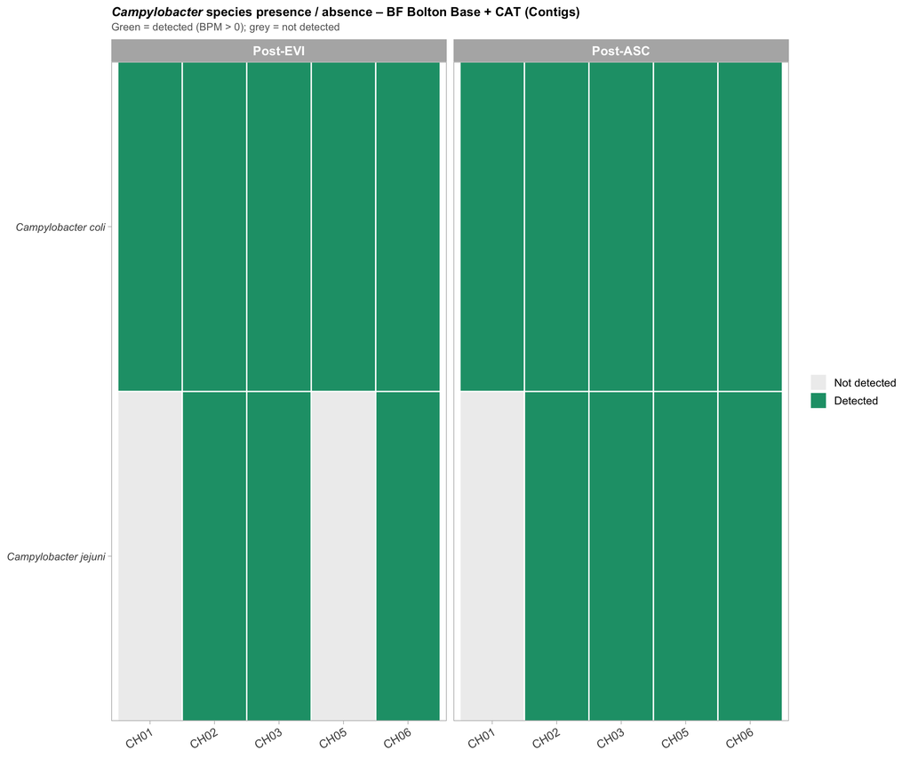

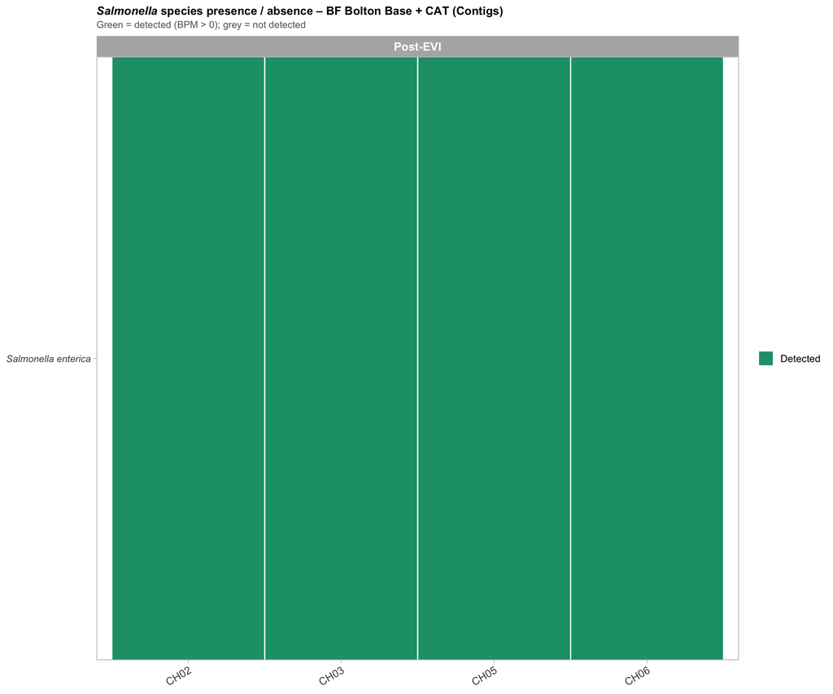

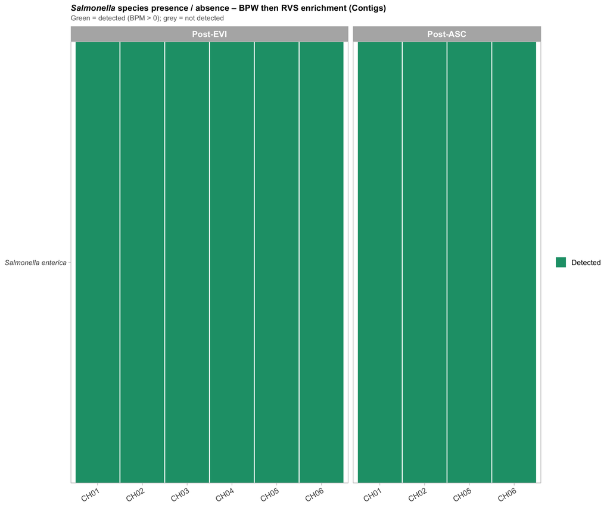

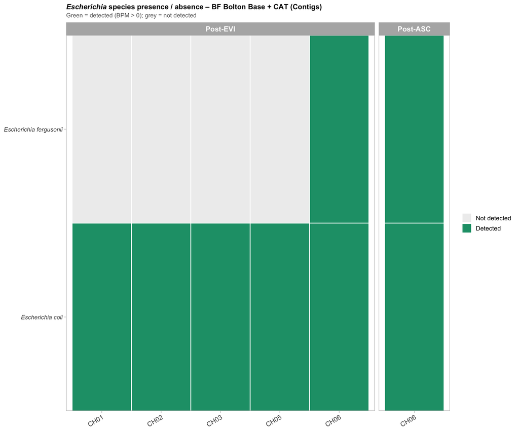

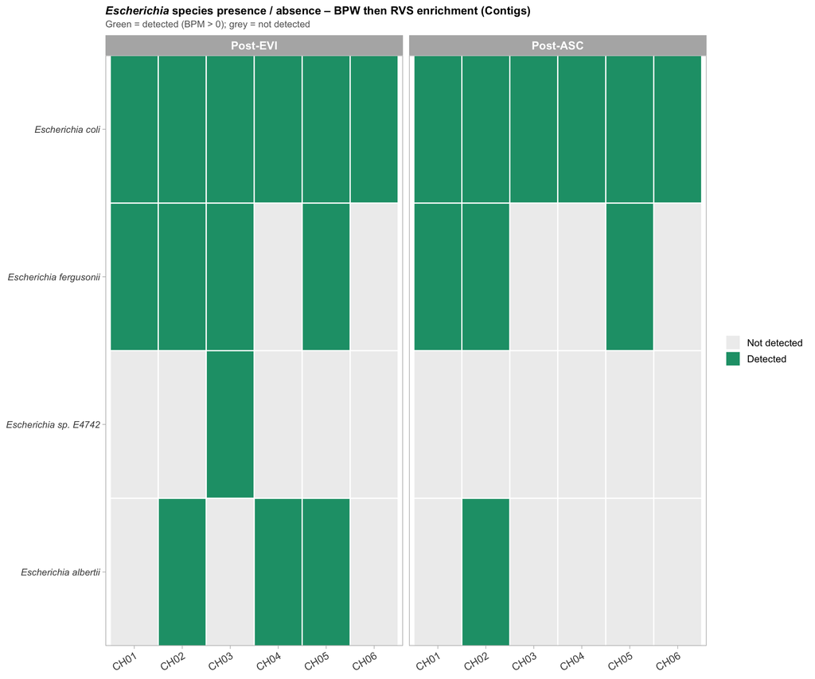

```r
pathogen_genera <- list(
  list(genus = "Campylobacter", slug = "campylobacter"),
  list(genus = "Salmonella",    slug = "salmonella"),
  list(genus = "Escherichia",   slug = "escherichia")
)

for (pg in pathogen_genera) {

  for (enrich in levels(df$enrichment_type)) {

    spp_df <- df %>%
      filter(tax_level == "species",
             str_detect(taxon, paste0("^", pg$genus)),
             enrichment_type == enrich) %>%
      rename(name = taxon)

    if (nrow(spp_df) == 0) {
      message("No ", pg$genus, " species data for: ", enrich, " — skipping.")
      next
    }

    enrich_lbl <- enrichment_labels[enrich]
    file_slug  <- gsub("[^A-Za-z0-9]", "_", enrich)

    plot_genus_presence(
      spp_df, spp_display_labels,
      title     = paste0("<i>", pg$genus, "</i> species presence / absence – ",
                         enrich_lbl, " (Contigs)"),
      subtitle  = "Green = detected (BPM > 0); grey = not detected",
      save_path = file.path(out_dir,
                            paste0(pg$slug, "_", file_slug, "_spp_presence.png"))
    )

    message(pg$genus, " presence done: ", enrich)
  }
}
```